# XGboost

610811101

2020/7/20

# 資料生成跑XGboost Feature Importances

## 資料一 (部分相關)

改變資料對regression沒有太大的差別。  
但是對XGboost來說train的MSE很好，但test的MSE卻很不好。

$x_{1 \sim 5}\sim MN(\mu_1 , \Sigma_1 )$  
$\mu_1=(0,0,0,0,0,0,0,0,0,0)$  
$\Sigma_1 = A^TDA$

$$D = \begin{pmatrix}
1 & 0 & 0 & 0 & 0 \\
0 & 1& 0 & 0 & 0 \\
0 & 0& 1 & 0 & 0 \\
0 & 0& 0 & 1 & 0 \\
0 & 0& 0 & 0 & 1
\end{pmatrix}$$

$$A = \begin{pmatrix}
0 & 2 & 2 & -2 & -1 \\
0 & 1& 0 & -2 & -2 \\
-1 & -2& 0 & 2 & 0 \\
-1 & -1& -2 & 0 & 1 \\
0 & 0& 1 & -1 & -2
\end{pmatrix}$$

$x_{6 \sim 10}\sim MN(\mu_2 , \Sigma_2 )$  
$\mu_2=(0,0,0,0,0,0,0,0,0,0)$

$$\Sigma_2 = \begin{pmatrix}
1 & 0 & 0 & 0 & 0 \\
0 & 1& 0 & 0 & 0 \\
0 & 0& 1 & 0 & 0 \\
0 & 0& 0 & 1 & 0 \\
0 & 0& 0 & 0 & 1
\end{pmatrix}$$

$x_{11} \sim N(0,1)$

$y=10x_1+5x_2-3x_3+4x_4+8x_5+10x_6+5x_7-3x_8+4x_9+8x_{10}+\epsilon$

$\epsilon \sim N(0,4)$

### 第一次

```r
#資料生成
set.seed(123)
a <- matrix(sample(-2:2,25,replace = T),5,5)
sigmas <- t(a)%*%diag(1,5)%*%a
set.seed(1253)
x <- rmvnorm(n = 100,mean = c(0,0,0,0,0),sigma = sigmas)
set.seed(173)
x2 <- rmvnorm(n = 100,mean = c(0,0,0,0,0),sigma = diag(1,5))
set.seed(59)
x_11 <- rnorm(n = 100)
set.seed(5)
sd <- rnorm(100,sd = 4)
y <- 10*x[,1]+5*x[,2]-3*x[,3]+4*x[,4]+8*x[,5]+10*x2[,1]+5*x2[,2]-3*x2[,3]+4*x2[,4]+8*x2[,5]+sd
sim <- data.frame(y,x,x2,x_11)


set.seed(192753)
x <- rmvnorm(n = 100,mean = c(0,0,0,0,0),sigma = sigmas)
set.seed(1783)
x2 <- rmvnorm(n = 100,mean = c(0,0,0,0,0),sigma = diag(1,5))
set.seed(599)
x_11 <- rnorm(n = 100)
set.seed(54)
sd <- rnorm(100,sd = 4)
y <- 10*x[,1]+5*x[,2]-3*x[,3]+4*x[,4]+8*x[,5]+10*x2[,1]+5*x2[,2]-3*x2[,3]+4*x2[,4]+8*x2[,5]+sd
sim_2 <- data.frame(y,x,x2,x_11)


set.seed(1962753)
x <- rmvnorm(n = 100,mean = c(0,0,0,0,0),sigma = sigmas)
set.seed(15783)
x2 <- rmvnorm(n = 100,mean = c(0,0,0,0,0),sigma = diag(1,5))
set.seed(4599)
x_11 <- rnorm(n = 100)
set.seed(534)
sd <- rnorm(100,sd = 4)
y <- 10*x[,1]+5*x[,2]-3*x[,3]+4*x[,4]+8*x[,5]+10*x2[,1]+5*x2[,2]-3*x2[,3]+4*x2[,4]+8*x2[,5]+sd
sim_3 <- data.frame(y,x,x2,x_11)

# sim_3 test data

names(sim) <- c("y",paste0("x",1:11))
names(sim_2) <- c("y",paste0("x",1:11))
names(sim_3) <- c("y",paste0("x",1:11))
```

#### use p-value to Variable Selection

```r
(old_data_lm <- lm(y~.,data = sim) %>% ols_step_forward_p())
```

```
##
##                              Selection Summary
## ----------------------------------------------------------------------------
##         Variable                  Adj.
## Step    Entered     R-Square    R-Square      C(p)         AIC        RMSE
## ----------------------------------------------------------------------------
##    1    x5            0.7033      0.7002    3774.7199    920.3771    23.6426
##    2    x1            0.8797      0.8772    1475.2366    832.0920    15.1311
##    3    x6            0.9244      0.9221     893.6843    787.5911    12.0544
##    4    x10           0.9617      0.9601     409.0857    721.5353     8.6226
##    5    x7            0.9769      0.9756     213.9178    673.2730     6.7421
##    6    x9            0.9834      0.9823     130.6655    642.0930     5.7420
##    7    x8            0.9892      0.9884      56.8344    601.0160     4.6545
##    8    x3            0.9906      0.9898      40.6392    589.1822     4.3672
##    9    x11           0.9911      0.9902      36.0718    585.6784     4.2722
## ----------------------------------------------------------------------------
```

```r
md <- formula(y~x1+x3+x5+x6+x7+x8+x9+x10+x11)
VS <- c(1,3,5,6,7,8,9,10,11)+1
```

##### old data

###### regression

```r
old_data_lm$model %>% summary()
```

```
##
## Call:
## lm(formula = paste(response, "~", paste(preds, collapse = " + ")),
##     data = l)
##
## Residuals:
##     Min      1Q  Median      3Q     Max
## -11.235  -2.617  -0.384   2.978  11.164
##
## Coefficients:
##             Estimate Std. Error t value Pr(>|t|)
## (Intercept)  -0.2161     0.4429  -0.488 0.626797
## x5           10.2149     0.1795  56.920  < 2e-16 ***
## x1           12.1012     0.3227  37.502  < 2e-16 ***
## x6            9.9106     0.4207  23.557  < 2e-16 ***
## x10           7.8328     0.4392  17.833  < 2e-16 ***
## x7            5.2866     0.4700  11.248  < 2e-16 ***
## x9            4.1017     0.4275   9.594 2.00e-15 ***
## x8           -3.3015     0.4735  -6.973 5.03e-10 ***
## x3           -0.8733     0.2340  -3.731 0.000333 ***
## x11           1.0229     0.4533   2.257 0.026453 *
## ---
## Signif. codes:  0 '***' 0.001 '**' 0.01 '*' 0.05 '.' 0.1 ' ' 1
##
## Residual standard error: 4.272 on 90 degrees of freedom
## Multiple R-squared:  0.9911, Adjusted R-squared:  0.9902
## F-statistic:  1114 on 9 and 90 DF,  p-value: < 2.2e-16
```

```r
print("train MSE")
```

```
## [1] "train MSE"
```

```r
label  <- old_data_lm$model %>% predict(sim)
mean((sim$y-label)^2)
```

```
## [1] 16.42668
```

```r
print("test MSE")
```

```
## [1] "test MSE"
```

```r
label  <- old_data_lm$model %>% predict(sim_3)
mean((sim_3$y-label)^2)
```

```
## [1] 26.73555
```

###### XGboost

```r
old_data_xgb <- xgboost(data = data.matrix(sim[,VS]),
label = sim[,"y"],
eta = 0.5,
max_depth = 10,
nround=25,
subsample = 0.7,
colsample_bytree = 0.7,
objective = "reg:squarederror",
verbose = 0
)
print("train MSE")
```

```
## [1] "train MSE"
```

```r
label  <- predict(old_data_xgb,xgb.DMatrix(data.matrix(sim[,VS])))
mean((sim$y-label)^2)
```

```
## [1] 0.06860337
```

```r
print("test MSE")
```

```
## [1] "test MSE"
```

```r
label  <- predict(old_data_xgb,xgb.DMatrix(data.matrix(sim_3[,VS])))
mean((sim_3$y-label)^2)
```

```
## [1] 302.5199
```

```r
xgb.importance(model = old_data_xgb)
```

| Feature | Gain | Cover | Frequency |
| --- | --- | --- | --- |
| x5 | 0.661374692 | 0.16386364 | 0.13261649 |
| x1 | 0.178858137 | 0.17143939 | 0.23178017 |
| x7 | 0.038024798 | 0.08560606 | 0.08960573 |
| x3 | 0.030338098 | 0.14340909 | 0.17323775 |
| x11 | 0.028851918 | 0.06598485 | 0.05973716 |
| x6 | 0.027101212 | 0.12303030 | 0.10872162 |
| x10 | 0.017395566 | 0.05250000 | 0.03703704 |
| x8 | 0.013518004 | 0.10674242 | 0.09916368 |
| x9 | 0.004537575 | 0.08742424 | 0.06810036 |

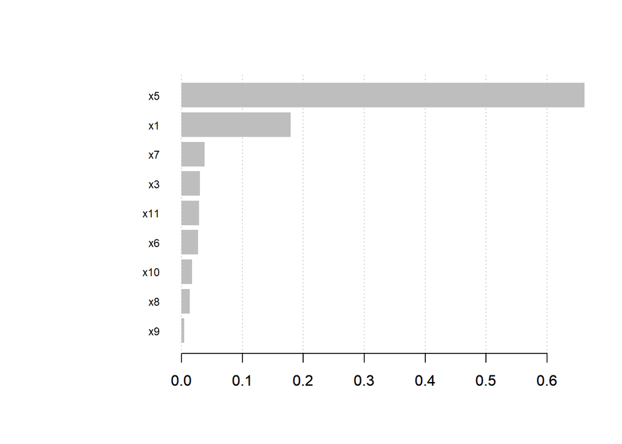

```r
xgb.importance(model = old_data_xgb) %>%
  xgb.plot.importance(top_n = 11)
```

##### new data

###### regression

```r
new_data_lm <- lm(md,data = sim_2)



new_data_lm %>% summary()
```

```
##
## Call:
## lm(formula = md, data = sim_2)
##
## Residuals:
##      Min       1Q   Median       3Q      Max
## -12.4443  -2.6729   0.1704   2.9378   9.5342
##
## Coefficients:
##             Estimate Std. Error t value Pr(>|t|)
## (Intercept)  -0.3143     0.4545  -0.691    0.491
## x1           12.6268     0.4120  30.649  < 2e-16 ***
## x3           -1.1295     0.2312  -4.886 4.45e-06 ***
## x5            9.8643     0.1889  52.221  < 2e-16 ***
## x6           10.2657     0.5047  20.340  < 2e-16 ***
## x7            4.4621     0.4733   9.428 4.43e-15 ***
## x8           -2.1612     0.4456  -4.851 5.13e-06 ***
## x9            4.2277     0.4791   8.825 7.97e-14 ***
## x10           8.1771     0.4707  17.372  < 2e-16 ***
## x11           0.4156     0.5091   0.816    0.416
## ---
## Signif. codes:  0 '***' 0.001 '**' 0.01 '*' 0.05 '.' 0.1 ' ' 1
##
## Residual standard error: 4.434 on 90 degrees of freedom
## Multiple R-squared:  0.9894, Adjusted R-squared:  0.9884
## F-statistic: 935.6 on 9 and 90 DF,  p-value: < 2.2e-16
```

```r
print("train MSE")
```

```
## [1] "train MSE"
```

```r
label  <- new_data_lm %>% predict(sim_2)
mean((sim_2$y-label)^2)
```

```
## [1] 17.69038
```

```r
print("test MSE")
```

```
## [1] "test MSE"
```

```r
label  <- new_data_lm %>% predict(sim_3)
mean((sim_3$y-label)^2)
```

```
## [1] 27.33
```

###### XGboost

```r
new_data_xgb <- xgboost(data = data.matrix(sim_2[,VS]),
label = sim_2[,"y"],
eta = 0.5,
max_depth = 10,
nround=25,
subsample = 0.7,
colsample_bytree = 0.7,
objective = "reg:squarederror",
verbose = 0
)
print("train MSE")
```

```
## [1] "train MSE"
```

```r
label  <- predict(new_data_xgb,xgb.DMatrix(data.matrix(sim_2[,VS])))
mean((sim_2$y-label)^2)
```

```
## [1] 0.1714403
```

```r
print("test MSE")
```

```
## [1] "test MSE"
```

```r
label  <- predict(new_data_xgb,xgb.DMatrix(data.matrix(sim_3[,VS])))
mean((sim_3$y-label)^2)
```

```
## [1] 610.3874
```

```r
xgb.importance(model = new_data_xgb)
```

| Feature | Gain | Cover | Frequency |
| --- | --- | --- | --- |
| x3 | 0.34714983 | 0.12173338 | 0.14426230 |
| x5 | 0.16400836 | 0.11974859 | 0.13551913 |
| x10 | 0.10519309 | 0.10635131 | 0.07759563 |
| x6 | 0.07967231 | 0.10841879 | 0.08524590 |
| x8 | 0.07687785 | 0.06409196 | 0.05792350 |
| x1 | 0.07379498 | 0.16134634 | 0.24153005 |
| x9 | 0.05732565 | 0.09179623 | 0.08524590 |
| x11 | 0.05188751 | 0.10585511 | 0.06775956 |
| x7 | 0.04409040 | 0.12065829 | 0.10491803 |

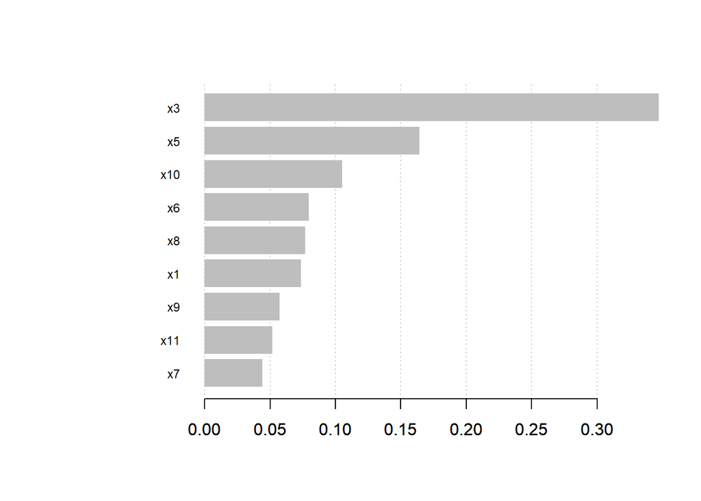

```r
xgb.importance(model = new_data_xgb) %>%
  xgb.plot.importance(top_n = 11)
```

#### use Gain to Variable Selection

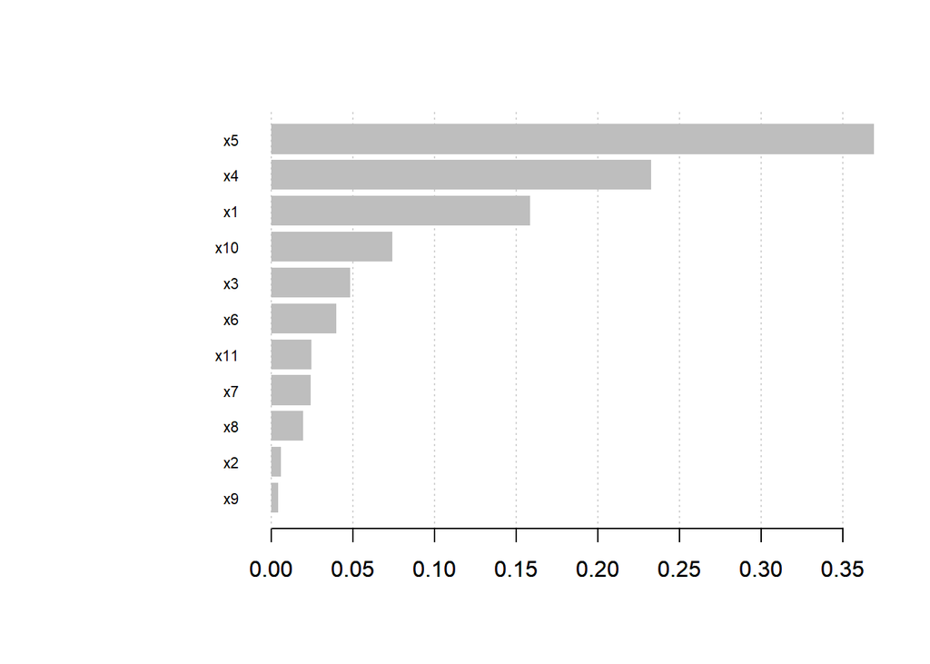

```r
xgb_test <- xgboost(data = data.matrix(sim[,-1]),
label = sim[,"y"],
eta = 0.5,
max_depth = 10,
nround=25,
subsample = 0.7,
colsample_bytree = 0.7,
objective = "reg:squarederror",
verbose = 0
)

xgb.importance(model = xgb_test) %>%
  xgb.plot.importance(top_n = 11)
```

```r
md <- formula(y~x1+x3+x4+x5+x6+x7+x8+x10+x11)
VS <- c(1,3,4,5,6,7,8,10,11)+1
```

##### old data

###### regression

```r
old_data_lm <- lm(md,data = sim)



old_data_lm %>% summary()
```

```
##
## Call:
## lm(formula = md, data = sim)
##
## Residuals:
##      Min       1Q   Median       3Q      Max
## -12.2238  -3.7382  -0.2247   4.5305  13.6215
##
## Coefficients:
##             Estimate Std. Error t value Pr(>|t|)
## (Intercept)  -0.3216     0.6263  -0.514 0.608823
## x1           12.4244     0.4810  25.831  < 2e-16 ***
## x3           -0.7913     0.3319  -2.384 0.019220 *
## x4            0.2744     0.2622   1.047 0.298105
## x5           10.0147     0.3401  29.446  < 2e-16 ***
## x6            9.4695     0.5936  15.953  < 2e-16 ***
## x7            5.3508     0.6649   8.047 3.26e-12 ***
## x8           -2.5788     0.6623  -3.894 0.000189 ***
## x10           7.3206     0.6243  11.727  < 2e-16 ***
## x11           0.7617     0.6403   1.190 0.237368
## ---
## Signif. codes:  0 '***' 0.001 '**' 0.01 '*' 0.05 '.' 0.1 ' ' 1
##
## Residual standard error: 6.039 on 90 degrees of freedom
## Multiple R-squared:  0.9822, Adjusted R-squared:  0.9804
## F-statistic: 552.4 on 9 and 90 DF,  p-value: < 2.2e-16
```

```r
print("train MSE")
```

```
## [1] "train MSE"
```

```r
label  <- old_data_lm %>% predict(sim)
mean((sim$y-label)^2)
```

```
## [1] 32.82715
```

```r
print("test MSE")
```

```
## [1] "test MSE"
```

```r
label  <- old_data_lm %>% predict(sim_3)
mean((sim_3$y-label)^2)
```

```
## [1] 35.61324
```

###### XGboost

```r
old_data_xgb <- xgboost(data = data.matrix(sim[,VS]),
label = sim[,"y"],
eta = 0.5,
max_depth = 10,
nround=25,
subsample = 0.7,
colsample_bytree = 0.7,
objective = "reg:squarederror",
verbose = 0
)
print("train MSE")
```

```
## [1] "train MSE"
```

```r
label  <- predict(old_data_xgb,xgb.DMatrix(data.matrix(sim[,VS])))
mean((sim$y-label)^2)
```

```
## [1] 0.03636192
```

```r
print("test MSE")
```

```
## [1] "test MSE"
```

```r
label  <- predict(old_data_xgb,xgb.DMatrix(data.matrix(sim_3[,VS])))
mean((sim_3$y-label)^2)
```

```
## [1] 310.2387
```

```r
xgb.importance(model = old_data_xgb)
```

| Feature | Gain | Cover | Frequency |
| --- | --- | --- | --- |
| x5 | 0.734022309 | 0.11315227 | 0.08535179 |
| x1 | 0.071265693 | 0.16446274 | 0.22606690 |
| x6 | 0.060044925 | 0.15211022 | 0.10495963 |
| x7 | 0.048578497 | 0.14688416 | 0.11880046 |
| x4 | 0.025411879 | 0.10103730 | 0.12456747 |
| x3 | 0.020756649 | 0.09897854 | 0.15570934 |
| x10 | 0.020236527 | 0.05503207 | 0.04844291 |
| x11 | 0.011094345 | 0.08733866 | 0.07151096 |
| x8 | 0.008589176 | 0.08100404 | 0.06459054 |

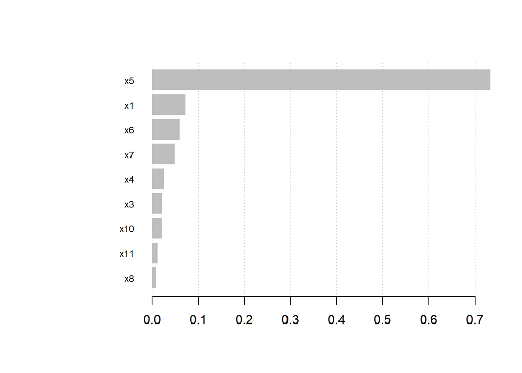

```r
xgb.importance(model = old_data_xgb) %>%
  xgb.plot.importance(top_n = 11)
```

##### new data

###### regression

```r
new_data_lm <- lm(md,data = sim_2)



new_data_lm %>% summary()
```

```
##
## Call:
## lm(formula = md, data = sim_2)
##
## Residuals:
##      Min       1Q   Median       3Q      Max
## -15.4000  -3.7107   0.2944   3.7469  13.4807
##
## Coefficients:
##             Estimate Std. Error t value Pr(>|t|)
## (Intercept)  -0.5643     0.6196  -0.911 0.364939
## x1           12.9405     0.5981  21.636  < 2e-16 ***
## x3           -1.4742     0.3245  -4.544 1.71e-05 ***
## x4           -0.1435     0.2909  -0.493 0.622986
## x5            9.9326     0.3826  25.962  < 2e-16 ***
## x6           10.2259     0.6888  14.846  < 2e-16 ***
## x7            4.6431     0.6453   7.195 1.79e-10 ***
## x8           -2.1654     0.6077  -3.563 0.000589 ***
## x10           7.3404     0.6298  11.656  < 2e-16 ***
## x11           0.7479     0.6925   1.080 0.283003
## ---
## Signif. codes:  0 '***' 0.001 '**' 0.01 '*' 0.05 '.' 0.1 ' ' 1
##
## Residual standard error: 6.047 on 90 degrees of freedom
## Multiple R-squared:  0.9803, Adjusted R-squared:  0.9784
## F-statistic: 498.3 on 9 and 90 DF,  p-value: < 2.2e-16
```

```r
print("train MSE")
```

```
## [1] "train MSE"
```

```r
label  <- new_data_lm %>% predict(sim_2)
mean((sim_2$y-label)^2)
```

```
## [1] 32.90914
```

```r
print("test MSE")
```

```
## [1] "test MSE"
```

```r
label  <- new_data_lm %>% predict(sim_3)
mean((sim_3$y-label)^2)
```

```
## [1] 36.12499
```

###### XGboost

```r
new_data_xgb <- xgboost(data = data.matrix(sim_2[,VS]),
label = sim_2[,"y"],
eta = 0.5,
max_depth = 10,
nround=25,
subsample = 0.7,
colsample_bytree = 0.7,
objective = "reg:squarederror",
verbose = 0
)
print("train MSE")
```

```
## [1] "train MSE"
```

```r
label  <- predict(new_data_xgb,xgb.DMatrix(data.matrix(sim_2[,VS])))
mean((sim_2$y-label)^2)
```

```
## [1] 0.03325458
```

```r
print("test MSE")
```

```
## [1] "test MSE"
```

```r
label  <- predict(new_data_xgb,xgb.DMatrix(data.matrix(sim_3[,VS])))
mean((sim_3$y-label)^2)
```

```
## [1] 262.1358
```

```r
xgb.importance(model = new_data_xgb)
```

| Feature | Gain | Cover | Frequency |
| --- | --- | --- | --- |
| x5 | 0.766184707 | 0.17355166 | 0.11951220 |
| x1 | 0.072907387 | 0.13082869 | 0.22804878 |
| x6 | 0.041594268 | 0.14071981 | 0.09878049 |
| x10 | 0.037656372 | 0.06466628 | 0.05243902 |
| x4 | 0.023540792 | 0.14928102 | 0.15243902 |
| x3 | 0.023455532 | 0.10963345 | 0.16951220 |
| x7 | 0.022907690 | 0.08270302 | 0.07317073 |
| x11 | 0.005887364 | 0.04638018 | 0.04024390 |
| x8 | 0.005865889 | 0.10223589 | 0.06585366 |

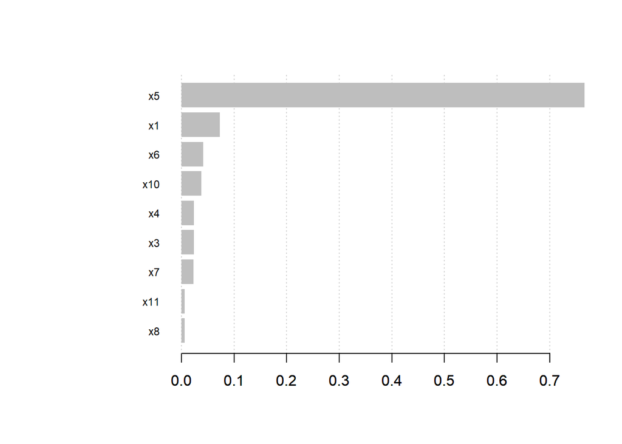

```r
xgb.importance(model = new_data_xgb) %>%
  xgb.plot.importance(top_n = 11)
```

### 第二次

```r
#資料生成
set.seed(123)
a <- matrix(sample(-2:2,25,replace = T),5,5)
sigmas <- t(a)%*%diag(1,5)%*%a
set.seed(155253)
x <- rmvnorm(n = 100,mean = c(0,0,0,0,0),sigma = sigmas)
set.seed(6173)
x2 <- rmvnorm(n = 100,mean = c(0,0,0,0,0),sigma = diag(1,5))
set.seed(579)
x_11 <- rnorm(n = 100)
set.seed(85)
sd <- rnorm(100,sd = 4)
y <- 10*x[,1]+5*x[,2]-3*x[,3]+4*x[,4]+8*x[,5]+10*x2[,1]+5*x2[,2]-3*x2[,3]+4*x2[,4]+8*x2[,5]+sd
sim <- data.frame(y,x,x2,x_11)


set.seed(19923)
x <- rmvnorm(n = 100,mean = c(0,0,0,0,0),sigma = sigmas)
set.seed(175483)
x2 <- rmvnorm(n = 100,mean = c(0,0,0,0,0),sigma = diag(1,5))
set.seed(5969)
x_11 <- rnorm(n = 100)
set.seed(547)
sd <- rnorm(100,sd = 4)
y <- 10*x[,1]+5*x[,2]-3*x[,3]+4*x[,4]+8*x[,5]+10*x2[,1]+5*x2[,2]-3*x2[,3]+4*x2[,4]+8*x2[,5]+sd
sim_2 <- data.frame(y,x,x2,x_11)


set.seed(1962752)
x <- rmvnorm(n = 100,mean = c(0,0,0,0,0),sigma = sigmas)
set.seed(15743)
x2 <- rmvnorm(n = 100,mean = c(0,0,0,0,0),sigma = diag(1,5))
set.seed(499)
x_11 <- rnorm(n = 100)
set.seed(5234)
sd <- rnorm(100,sd = 4)
y <- 10*x[,1]+5*x[,2]-3*x[,3]+4*x[,4]+8*x[,5]+10*x2[,1]+5*x2[,2]-3*x2[,3]+4*x2[,4]+8*x2[,5]+sd
sim_3 <- data.frame(y,x,x2,x_11)



names(sim) <- c("y",paste0("x",1:11))
names(sim_2) <- c("y",paste0("x",1:11))
names(sim_3) <- c("y",paste0("x",1:11))
```

#### use p-value to Variable Selection

```r
(old_data_lm <- lm(y~.,data = sim) %>% ols_step_forward_p())
```

```
##
##                              Selection Summary
## ----------------------------------------------------------------------------
##         Variable                  Adj.
## Step    Entered     R-Square    R-Square      C(p)         AIC        RMSE
## ----------------------------------------------------------------------------
##    1    x5            0.6370      0.6333    3007.7495    907.0905    22.1229
##    2    x1            0.7972      0.7930    1640.4912    850.9008    16.6231
##    3    x6            0.8952      0.8919     803.9403    786.8412    12.0093
##    4    x10           0.9417      0.9392     408.9263    730.2997     9.0088
##    5    x7            0.9545      0.9521     300.7665    707.3517     7.9945
##    6    x9            0.9684      0.9664     183.9034    672.8603     6.6969
##    7    x8            0.9787      0.9771      97.9599    635.4325     5.5285
##    8    x3            0.9852      0.9839      44.3610    600.9681     4.6323
##    9    x2            0.9862      0.9848      38.2215    596.3098     4.5055
##   10    x4            0.9894      0.9882      12.3614    571.4355     3.9610
##   11    x11           0.9897      0.9884      12.0000    570.7875     3.9311
## ----------------------------------------------------------------------------
```

```r
md <- formula(y~.)
VS <- 1:11+1
```

##### old data

###### regression

```r
old_data_lm$model %>% summary()
```

```
##
## Call:
## lm(formula = paste(response, "~", paste(preds, collapse = " + ")),
##     data = l)
##
## Residuals:
##     Min      1Q  Median      3Q     Max
## -8.4214 -2.5767 -0.2822  2.1791  8.9720
##
## Coefficients:
##             Estimate Std. Error t value Pr(>|t|)
## (Intercept)  -1.5321     0.4024  -3.807 0.000259 ***
## x5            7.9547     0.4712  16.880  < 2e-16 ***
## x1           10.2526     0.6102  16.802  < 2e-16 ***
## x6           10.2051     0.3874  26.341  < 2e-16 ***
## x10           8.2819     0.4576  18.099  < 2e-16 ***
## x7            4.7352     0.4283  11.055  < 2e-16 ***
## x9            3.8166     0.4061   9.398 6.22e-15 ***
## x8           -3.2810     0.4037  -8.127 2.56e-12 ***
## x3           -3.3532     0.3969  -8.448 5.61e-13 ***
## x2            5.1065     0.9029   5.656 1.90e-07 ***
## x4            3.8893     0.7663   5.075 2.14e-06 ***
## x11          -0.5852     0.3808  -1.537 0.127961
## ---
## Signif. codes:  0 '***' 0.001 '**' 0.01 '*' 0.05 '.' 0.1 ' ' 1
##
## Residual standard error: 3.931 on 88 degrees of freedom
## Multiple R-squared:  0.9897, Adjusted R-squared:  0.9884
## F-statistic: 769.4 on 11 and 88 DF,  p-value: < 2.2e-16
```

```r
print("train MSE")
```

```
## [1] "train MSE"
```

```r
label  <- old_data_lm$model %>% predict(sim)
mean((sim$y-label)^2)
```

```
## [1] 13.59903
```

```r
print("test MSE")
```

```
## [1] "test MSE"
```

```r
label  <- old_data_lm$model %>% predict(sim_3)
mean((sim_3$y-label)^2)
```

```
## [1] 19.74559
```

###### XGboost

```r
old_data_xgb <- xgboost(data = data.matrix(sim[,VS]),
label = sim[,"y"],
eta = 0.5,
max_depth = 10,
nround=25,
subsample = 0.7,
colsample_bytree = 0.7,
objective = "reg:squarederror",
verbose = 0
)
print("train MSE")
```

```
## [1] "train MSE"
```

```r
label  <- predict(old_data_xgb,xgb.DMatrix(data.matrix(sim[,VS])))
mean((sim$y-label)^2)
```

```
## [1] 0.03361275
```

```r
print("test MSE")
```

```
## [1] "test MSE"
```

```r
label  <- predict(old_data_xgb,xgb.DMatrix(data.matrix(sim_3[,VS])))
mean((sim_3$y-label)^2)
```

```
## [1] 417.5837
```

```r
xgb.importance(model = old_data_xgb)
```

| Feature | Gain | Cover | Frequency |
| --- | --- | --- | --- |
| x5 | 0.48213810 | 0.11026523 | 0.06478210 |
| x1 | 0.10767537 | 0.13318599 | 0.26383981 |
| x6 | 0.09581792 | 0.11910609 | 0.07773852 |
| x10 | 0.07676160 | 0.05026195 | 0.04358068 |
| x3 | 0.05671995 | 0.07760314 | 0.09540636 |
| x9 | 0.05197185 | 0.10682711 | 0.06007067 |
| x7 | 0.03959509 | 0.07056320 | 0.06360424 |
| x2 | 0.02881107 | 0.08218730 | 0.14369847 |
| x4 | 0.02416485 | 0.08939096 | 0.07067138 |
| x11 | 0.02275053 | 0.06491487 | 0.05182568 |

[output cut: 1 more lines]

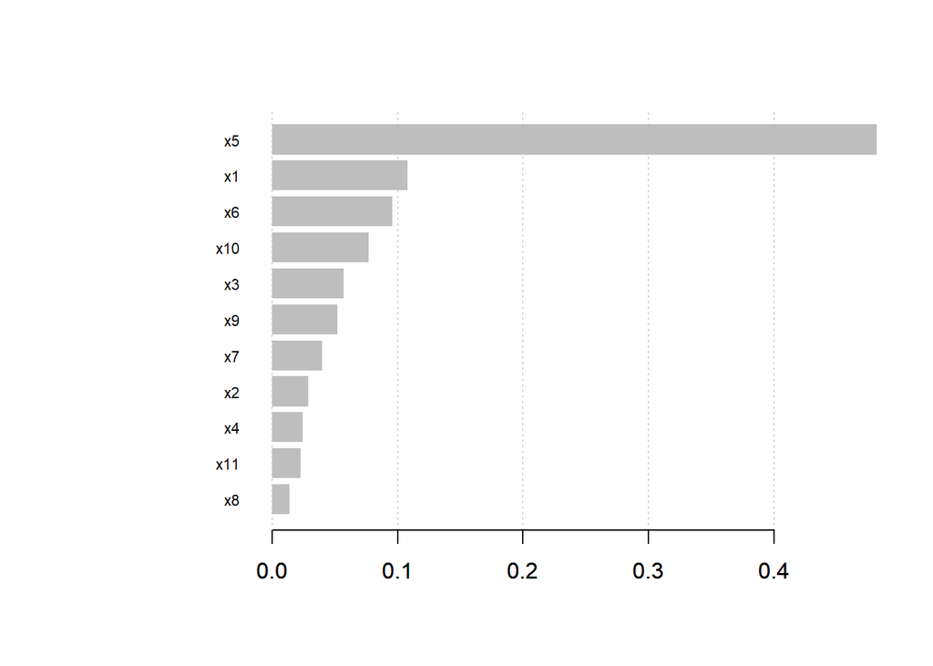

```r
xgb.importance(model = old_data_xgb) %>%
  xgb.plot.importance(top_n = 11)
```

##### new data

###### regression

```r
new_data_lm <- lm(md,data = sim_2)



new_data_lm %>% summary()
```

```
##
## Call:
## lm(formula = md, data = sim_2)
##
## Residuals:
##     Min      1Q  Median      3Q     Max
## -12.335  -2.154   0.178   2.617   9.592
##
## Coefficients:
##             Estimate Std. Error t value Pr(>|t|)
## (Intercept)  -0.2615     0.4625  -0.565    0.573
## x1           10.2965     0.6560  15.695  < 2e-16 ***
## x2            5.0567     0.9255   5.464 4.28e-07 ***
## x3           -3.2868     0.4643  -7.079 3.37e-10 ***
## x4            4.3908     0.8195   5.358 6.68e-07 ***
## x5            7.7608     0.5471  14.185  < 2e-16 ***
## x6           10.6906     0.5255  20.343  < 2e-16 ***
## x7            4.4273     0.4716   9.388 6.52e-15 ***
## x8           -1.9728     0.4725  -4.175 6.98e-05 ***
## x9            4.1167     0.4864   8.464 5.20e-13 ***
## x10           7.8576     0.4542  17.298  < 2e-16 ***
## x11          -0.2568     0.5123  -0.501    0.617
## ---
## Signif. codes:  0 '***' 0.001 '**' 0.01 '*' 0.05 '.' 0.1 ' ' 1
##
## Residual standard error: 4.421 on 88 degrees of freedom
## Multiple R-squared:  0.9874, Adjusted R-squared:  0.9858
## F-statistic: 627.4 on 11 and 88 DF,  p-value: < 2.2e-16
```

```r
print("train MSE")
```

```
## [1] "train MSE"
```

```r
label  <- new_data_lm %>% predict(sim_2)
mean((sim_2$y-label)^2)
```

```
## [1] 17.19813
```

```r
print("test MSE")
```

```
## [1] "test MSE"
```

```r
label  <- new_data_lm %>% predict(sim_3)
mean((sim_3$y-label)^2)
```

```
## [1] 18.56505
```

###### XGboost

```r
new_data_xgb <- xgboost(data = data.matrix(sim_2[,VS]),
label = sim_2[,"y"],
eta = 0.5,
max_depth = 10,
nround=25,
subsample = 0.7,
colsample_bytree = 0.7,
objective = "reg:squarederror",
verbose = 0
)
print("train MSE")
```

```
## [1] "train MSE"
```

```r
label  <- predict(new_data_xgb,xgb.DMatrix(data.matrix(sim_2[,VS])))
mean((sim_2$y-label)^2)
```

```
## [1] 0.06427865
```

```r
print("test MSE")
```

```
## [1] "test MSE"
```

```r
label  <- predict(new_data_xgb,xgb.DMatrix(data.matrix(sim_3[,VS])))
mean((sim_3$y-label)^2)
```

```
## [1] 435.1889
```

```r
xgb.importance(model = new_data_xgb)
```

| Feature | Gain | Cover | Frequency |
| --- | --- | --- | --- |
| x5 | 0.610915906 | 0.13450563 | 0.08121212 |
| x4 | 0.061315069 | 0.11653555 | 0.07515152 |
| x8 | 0.058877541 | 0.07859016 | 0.05454545 |
| x1 | 0.056609559 | 0.11591856 | 0.26909091 |
| x2 | 0.054778283 | 0.06586457 | 0.11393939 |
| x6 | 0.036578929 | 0.09848835 | 0.08000000 |
| x10 | 0.034317491 | 0.07820453 | 0.06787879 |
| x3 | 0.033999070 | 0.07041493 | 0.08848485 |
| x11 | 0.021982240 | 0.09848835 | 0.05696970 |
| x9 | 0.020963780 | 0.09332099 | 0.07151515 |

[output cut: 1 more lines]

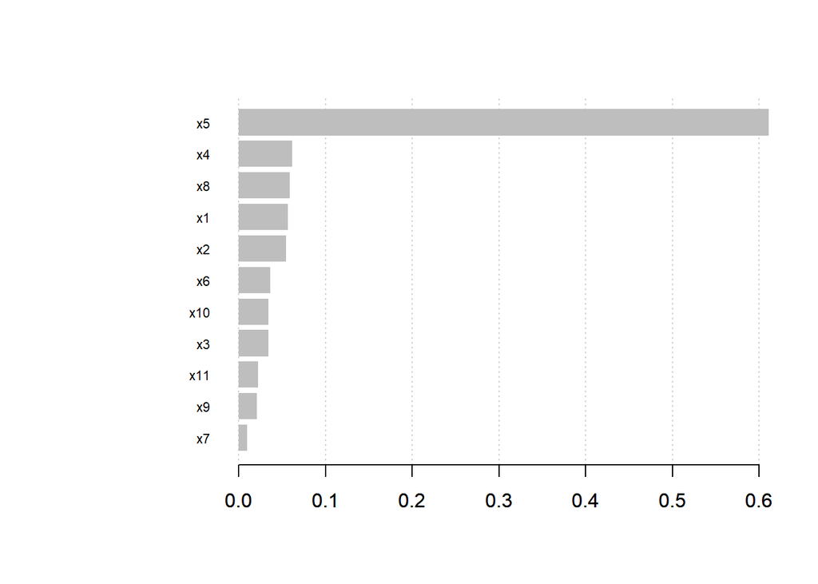

```r
xgb.importance(model = new_data_xgb) %>%
  xgb.plot.importance(top_n = 11)
```

#### use Gain to Variable Selection

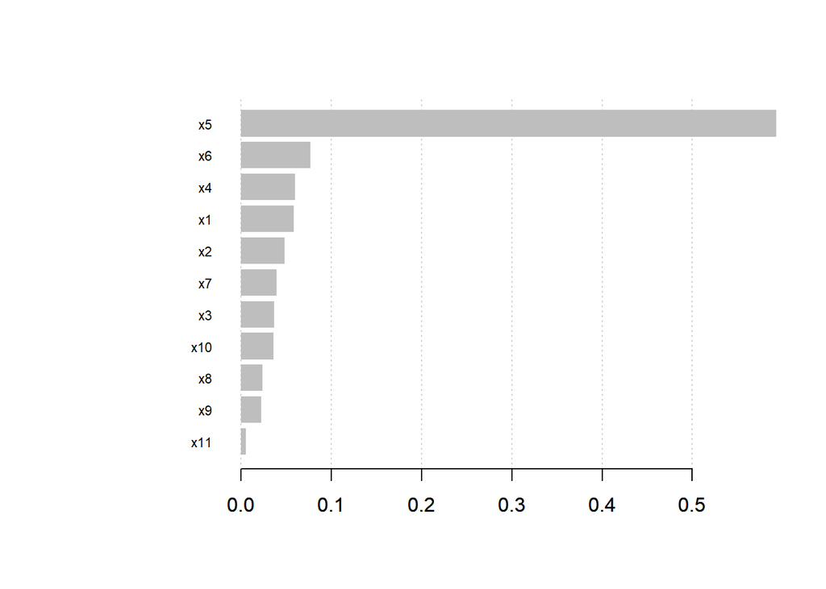

```r
xgb_test <- xgboost(data = data.matrix(sim[,-1]),
label = sim[,"y"],
eta = 0.5,
max_depth = 10,
nround=25,
subsample = 0.7,
colsample_bytree = 0.7,
objective = "reg:squarederror",
verbose = 0
)

xgb.importance(model = xgb_test) %>%
  xgb.plot.importance(top_n = 11)
```

```r
md <- formula(y~.)
VS <- 1:11+1
```

##### old data

###### regression

```r
old_data_lm <- lm(md,data = sim)



old_data_lm %>% summary()
```

```
##
## Call:
## lm(formula = md, data = sim)
##
## Residuals:
##     Min      1Q  Median      3Q     Max
## -8.4214 -2.5767 -0.2822  2.1791  8.9720
##
## Coefficients:
##             Estimate Std. Error t value Pr(>|t|)
## (Intercept)  -1.5321     0.4024  -3.807 0.000259 ***
## x1           10.2526     0.6102  16.802  < 2e-16 ***
## x2            5.1065     0.9029   5.656 1.90e-07 ***
## x3           -3.3532     0.3969  -8.448 5.61e-13 ***
## x4            3.8893     0.7663   5.075 2.14e-06 ***
## x5            7.9547     0.4712  16.880  < 2e-16 ***
## x6           10.2051     0.3874  26.341  < 2e-16 ***
## x7            4.7352     0.4283  11.055  < 2e-16 ***
## x8           -3.2810     0.4037  -8.127 2.56e-12 ***
## x9            3.8166     0.4061   9.398 6.22e-15 ***
## x10           8.2819     0.4576  18.099  < 2e-16 ***
## x11          -0.5852     0.3808  -1.537 0.127961
## ---
## Signif. codes:  0 '***' 0.001 '**' 0.01 '*' 0.05 '.' 0.1 ' ' 1
##
## Residual standard error: 3.931 on 88 degrees of freedom
## Multiple R-squared:  0.9897, Adjusted R-squared:  0.9884
## F-statistic: 769.4 on 11 and 88 DF,  p-value: < 2.2e-16
```

```r
print("train MSE")
```

```
## [1] "train MSE"
```

```r
label  <- old_data_lm %>% predict(sim)
mean((sim$y-label)^2)
```

```
## [1] 13.59903
```

```r
print("test MSE")
```

```
## [1] "test MSE"
```

```r
label  <- old_data_lm %>% predict(sim_3)
mean((sim_3$y-label)^2)
```

```
## [1] 19.74559
```

###### XGboost

```r
old_data_xgb <- xgboost(data = data.matrix(sim[,VS]),
label = sim[,"y"],
eta = 0.5,
max_depth = 10,
nround=25,
subsample = 0.7,
colsample_bytree = 0.7,
objective = "reg:squarederror",
verbose = 0
)
print("train MSE")
```

```
## [1] "train MSE"
```

```r
label  <- predict(old_data_xgb,xgb.DMatrix(data.matrix(sim[,VS])))
mean((sim$y-label)^2)
```

```
## [1] 0.04554648
```

```r
print("test MSE")
```

```
## [1] "test MSE"
```

```r
label  <- predict(old_data_xgb,xgb.DMatrix(data.matrix(sim_3[,VS])))
mean((sim_3$y-label)^2)
```

```
## [1] 460.2465
```

```r
xgb.importance(model = old_data_xgb)
```

| Feature | Gain | Cover | Frequency |
| --- | --- | --- | --- |
| x5 | 0.528748443 | 0.15723007 | 0.09413203 |
| x1 | 0.127327794 | 0.13439826 | 0.21271394 |
| x3 | 0.092975310 | 0.09709793 | 0.11002445 |
| x8 | 0.052182451 | 0.07401522 | 0.06479218 |
| x7 | 0.044637667 | 0.09734883 | 0.09413203 |
| x9 | 0.041697403 | 0.07761144 | 0.06234719 |
| x2 | 0.032692477 | 0.08865100 | 0.15403423 |
| x10 | 0.031924425 | 0.07986953 | 0.04889976 |
| x6 | 0.026135460 | 0.06305930 | 0.05867971 |
| x11 | 0.013390459 | 0.05770678 | 0.04523227 |

[output cut: 1 more lines]

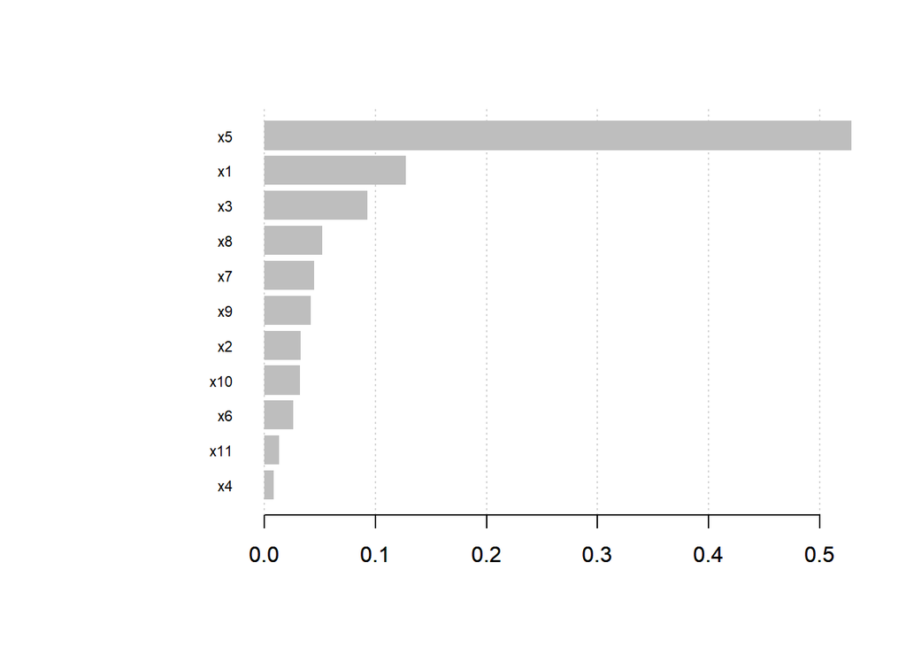

```r
xgb.importance(model = old_data_xgb) %>%
  xgb.plot.importance(top_n = 11)
```

##### new data

###### regression

```r
new_data_lm <- lm(md,data = sim_2)



new_data_lm %>% summary()
```

```
##
## Call:
## lm(formula = md, data = sim_2)
##
## Residuals:
##     Min      1Q  Median      3Q     Max
## -12.335  -2.154   0.178   2.617   9.592
##
## Coefficients:
##             Estimate Std. Error t value Pr(>|t|)
## (Intercept)  -0.2615     0.4625  -0.565    0.573
## x1           10.2965     0.6560  15.695  < 2e-16 ***
## x2            5.0567     0.9255   5.464 4.28e-07 ***
## x3           -3.2868     0.4643  -7.079 3.37e-10 ***
## x4            4.3908     0.8195   5.358 6.68e-07 ***
## x5            7.7608     0.5471  14.185  < 2e-16 ***
## x6           10.6906     0.5255  20.343  < 2e-16 ***
## x7            4.4273     0.4716   9.388 6.52e-15 ***
## x8           -1.9728     0.4725  -4.175 6.98e-05 ***
## x9            4.1167     0.4864   8.464 5.20e-13 ***
## x10           7.8576     0.4542  17.298  < 2e-16 ***
## x11          -0.2568     0.5123  -0.501    0.617
## ---
## Signif. codes:  0 '***' 0.001 '**' 0.01 '*' 0.05 '.' 0.1 ' ' 1
##
## Residual standard error: 4.421 on 88 degrees of freedom
## Multiple R-squared:  0.9874, Adjusted R-squared:  0.9858
## F-statistic: 627.4 on 11 and 88 DF,  p-value: < 2.2e-16
```

```r
print("train MSE")
```

```
## [1] "train MSE"
```

```r
label  <- new_data_lm %>% predict(sim_2)
mean((sim_2$y-label)^2)
```

```
## [1] 17.19813
```

```r
print("test MSE")
```

```
## [1] "test MSE"
```

```r
label  <- new_data_lm %>% predict(sim_3)
mean((sim_3$y-label)^2)
```

```
## [1] 18.56505
```

###### XGboost

```r
new_data_xgb <- xgboost(data = data.matrix(sim_2[,VS]),
label = sim_2[,"y"],
eta = 0.5,
max_depth = 10,
nround=25,
subsample = 0.7,
colsample_bytree = 0.7,
objective = "reg:squarederror",
verbose = 0
)
print("train MSE")
```

```
## [1] "train MSE"
```

```r
label  <- predict(new_data_xgb,xgb.DMatrix(data.matrix(sim_2[,VS])))
mean((sim_2$y-label)^2)
```

```
## [1] 0.02463607
```

```r
print("test MSE")
```

```
## [1] "test MSE"
```

```r
label  <- predict(new_data_xgb,xgb.DMatrix(data.matrix(sim_3[,VS])))
mean((sim_3$y-label)^2)
```

```
## [1] 328.1947
```

```r
xgb.importance(model = new_data_xgb)
```

| Feature | Gain | Cover | Frequency |
| --- | --- | --- | --- |
| x5 | 0.648252628 | 0.16118048 | 0.08180708 |
| x1 | 0.108568900 | 0.09445435 | 0.20024420 |
| x6 | 0.083720142 | 0.07645533 | 0.06471306 |
| x4 | 0.053096197 | 0.17561213 | 0.12942613 |
| x10 | 0.047511631 | 0.07005027 | 0.04151404 |
| x7 | 0.021680993 | 0.05869953 | 0.06715507 |
| x8 | 0.014854656 | 0.06453705 | 0.06227106 |
| x2 | 0.007413522 | 0.09113021 | 0.15873016 |
| x9 | 0.006463269 | 0.06948273 | 0.06471306 |
| x3 | 0.005030767 | 0.07613102 | 0.07570208 |

[output cut: 1 more lines]

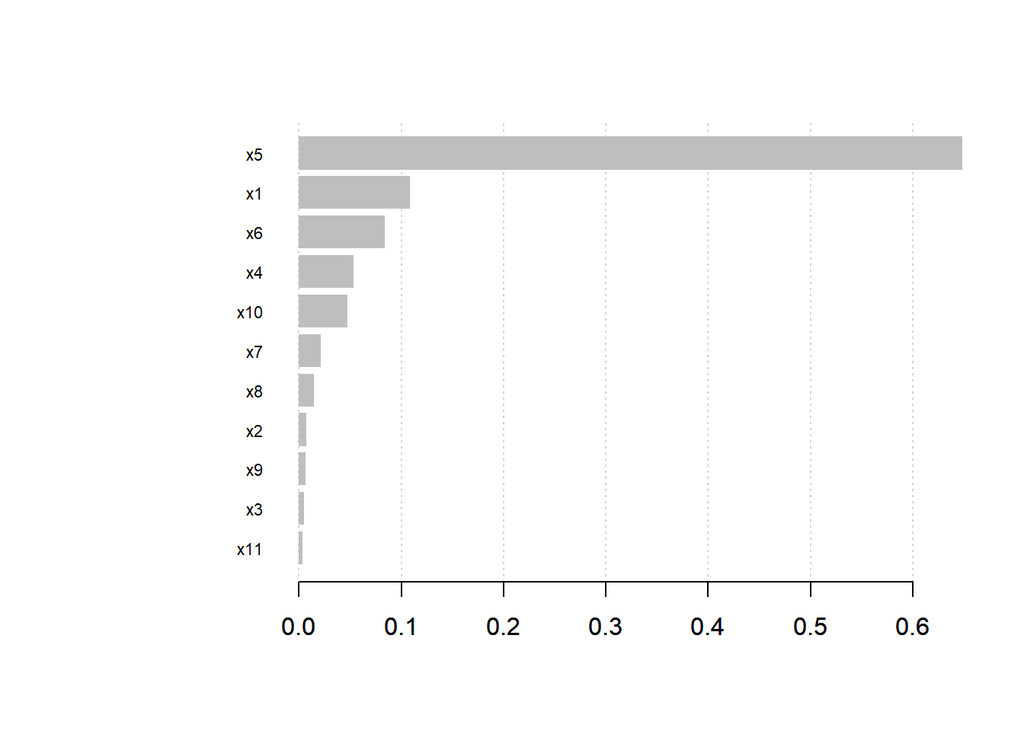

```r
xgb.importance(model = new_data_xgb) %>%
  xgb.plot.importance(top_n = 11)
```

### 第三次

```r
#資料生成
set.seed(123)
a <- matrix(sample(-2:2,25,replace = T),5,5)
sigmas <- t(a)%*%diag(1,5)%*%a
set.seed(12536)
x <- rmvnorm(n = 100,mean = c(0,0,0,0,0),sigma = sigmas)
set.seed(1783)
x2 <- rmvnorm(n = 100,mean = c(0,0,0,0,0),sigma = diag(1,5))
set.seed(519)
x_11 <- rnorm(n = 100)
set.seed(53)
sd <- rnorm(100,sd = 4)
y <- 10*x[,1]+5*x[,2]-3*x[,3]+4*x[,4]+8*x[,5]+10*x2[,1]+5*x2[,2]-3*x2[,3]+4*x2[,4]+8*x2[,5]+sd
sim <- data.frame(y,x,x2,x_11)


set.seed(17773)
x <- rmvnorm(n = 100,mean = c(0,0,0,0,0),sigma = sigmas)
set.seed(18783)
x2 <- rmvnorm(n = 100,mean = c(0,0,0,0,0),sigma = diag(1,5))
set.seed(5994)
x_11 <- rnorm(n = 100)
set.seed(84)
sd <- rnorm(100,sd = 4)
y <- 10*x[,1]+5*x[,2]-3*x[,3]+4*x[,4]+8*x[,5]+10*x2[,1]+5*x2[,2]-3*x2[,3]+4*x2[,4]+8*x2[,5]+sd
sim_2 <- data.frame(y,x,x2,x_11)


set.seed(162752)
x <- rmvnorm(n = 100,mean = c(0,0,0,0,0),sigma = sigmas)
set.seed(1583)
x2 <- rmvnorm(n = 100,mean = c(0,0,0,0,0),sigma = diag(1,5))
set.seed(459)
x_11 <- rnorm(n = 100)
set.seed(94)
sd <- rnorm(100,sd = 4)
y <- 10*x[,1]+5*x[,2]-3*x[,3]+4*x[,4]+8*x[,5]+10*x2[,1]+5*x2[,2]-3*x2[,3]+4*x2[,4]+8*x2[,5]+sd
sim_3 <- data.frame(y,x,x2,x_11)



names(sim) <- c("y",paste0("x",1:11))
names(sim_2) <- c("y",paste0("x",1:11))
names(sim_3) <- c("y",paste0("x",1:11))
```

#### use p-value to Variable Selection

```r
(old_data_lm <- lm(y~.,data = sim) %>% ols_step_forward_p())
```

```
##
##                              Selection Summary
## ----------------------------------------------------------------------------
##         Variable                  Adj.
## Step    Entered     R-Square    R-Square      C(p)         AIC        RMSE
## ----------------------------------------------------------------------------
##    1    x5            0.7096      0.7067    2731.9701    896.7323    21.0063
##    2    x1            0.8708      0.8681    1164.7822    817.7909    14.0869
##    3    x6            0.9134      0.9107     751.2266    779.7245    11.5894
##    4    x10           0.9501      0.9480     396.1059    726.6435     8.8456
##    5    x9            0.9632      0.9613     270.3242    698.1447     7.6348
##    6    x8            0.9748      0.9732     159.4650    662.3163     6.3530
##    7    x7            0.9840      0.9827      72.2483    619.1455     5.0961
##    8    x3            0.9888      0.9878      26.9611    585.1000     4.2790
##    9    x11           0.9890      0.9879      27.1783    585.4503     4.2674
## ----------------------------------------------------------------------------
```

```r
md <- formula(y~x1+x3+x5+x6+x7+x8+x9+x10+x11)
VS <- c(1,3,5,6,7,8,9,10,11)+1
```

##### old data

###### regression

```r
old_data_lm$model %>% summary()
```

```
##
## Call:
## lm(formula = paste(response, "~", paste(preds, collapse = " + ")),
##     data = l)
##
## Residuals:
##     Min      1Q  Median      3Q     Max
## -8.8362 -3.0463  0.1014  2.9276  8.5149
##
## Coefficients:
##             Estimate Std. Error t value Pr(>|t|)
## (Intercept)  -0.3401     0.4380  -0.777    0.439
## x5           10.0098     0.1713  58.425  < 2e-16 ***
## x1           12.8210     0.3554  36.077  < 2e-16 ***
## x6           10.1324     0.4793  21.139  < 2e-16 ***
## x10           7.9479     0.4319  18.404  < 2e-16 ***
## x9            4.2998     0.4520   9.513 2.94e-15 ***
## x8           -3.5252     0.4241  -8.312 9.23e-13 ***
## x7            4.2237     0.4447   9.498 3.17e-15 ***
## x3           -1.4317     0.2254  -6.351 8.53e-09 ***
## x11          -0.5239     0.4282  -1.224    0.224
## ---
## Signif. codes:  0 '***' 0.001 '**' 0.01 '*' 0.05 '.' 0.1 ' ' 1
##
## Residual standard error: 4.267 on 90 degrees of freedom
## Multiple R-squared:  0.989,  Adjusted R-squared:  0.9879
## F-statistic: 898.7 on 9 and 90 DF,  p-value: < 2.2e-16
```

```r
print("train MSE")
```

```
## [1] "train MSE"
```

```r
label  <- old_data_lm$model %>% predict(sim)
mean((sim$y-label)^2)
```

```
## [1] 16.38925
```

```r
print("test MSE")
```

```
## [1] "test MSE"
```

```r
label  <- old_data_lm$model %>% predict(sim_3)
mean((sim_3$y-label)^2)
```

```
## [1] 25.49665
```

###### XGboost

```r
old_data_xgb <- xgboost(data = data.matrix(sim[,VS]),
label = sim[,"y"],
eta = 0.5,
max_depth = 10,
nround=25,
subsample = 0.7,
colsample_bytree = 0.7,
objective = "reg:squarederror",
verbose = 0
)
print("train MSE")
```

```
## [1] "train MSE"
```

```r
label  <- predict(old_data_xgb,xgb.DMatrix(data.matrix(sim[,VS])))
mean((sim$y-label)^2)
```

```
## [1] 0.01061575
```

```r
print("test MSE")
```

```
## [1] "test MSE"
```

```r
label  <- predict(old_data_xgb,xgb.DMatrix(data.matrix(sim_3[,VS])))
mean((sim_3$y-label)^2)
```

```
## [1] 441.5638
```

```r
xgb.importance(model = old_data_xgb)
```

| Feature | Gain | Cover | Frequency |
| --- | --- | --- | --- |
| x5 | 0.643068755 | 0.20014497 | 0.16287425 |
| x1 | 0.107848664 | 0.14070853 | 0.20838323 |
| x8 | 0.071904504 | 0.08226873 | 0.07305389 |
| x6 | 0.042730817 | 0.11579233 | 0.11616766 |
| x3 | 0.038632197 | 0.13065145 | 0.15209581 |
| x11 | 0.033555001 | 0.11234937 | 0.07784431 |
| x10 | 0.030699783 | 0.05862100 | 0.05748503 |
| x9 | 0.029466474 | 0.09486273 | 0.08862275 |
| x7 | 0.002093805 | 0.06460089 | 0.06347305 |

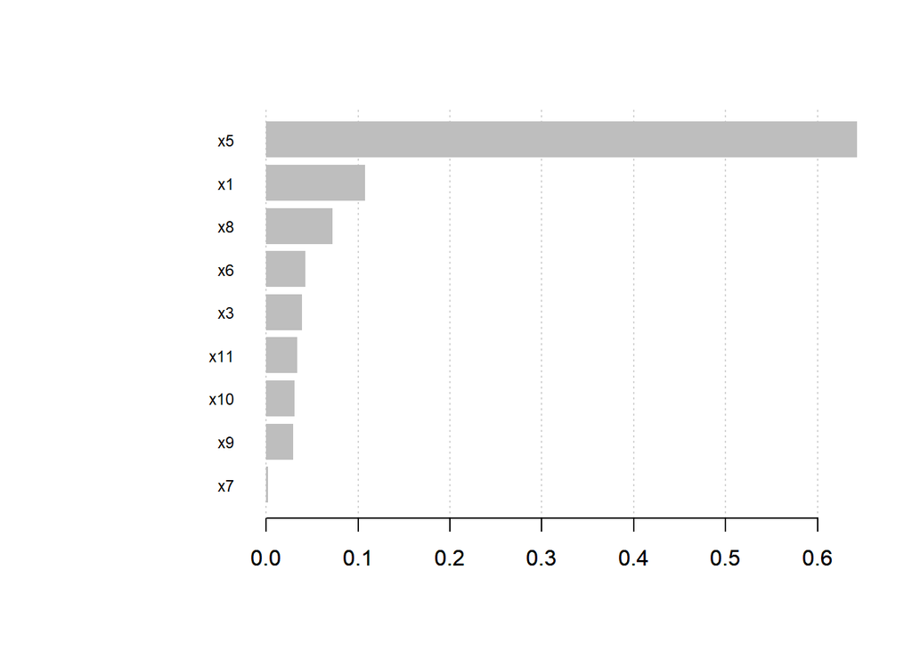

```r
xgb.importance(model = old_data_xgb) %>%
  xgb.plot.importance(top_n = 11)
```

##### new data

###### regression

```r
new_data_lm <- lm(md,data = sim_2)



new_data_lm %>% summary()
```

```
##
## Call:
## lm(formula = md, data = sim_2)
##
## Residuals:
##     Min      1Q  Median      3Q     Max
## -8.9874 -2.5233 -0.2476  2.9722  7.2675
##
## Coefficients:
##             Estimate Std. Error t value Pr(>|t|)
## (Intercept)   0.5541     0.4255   1.302    0.196
## x1           13.1538     0.3524  37.322  < 2e-16 ***
## x3           -1.2472     0.2097  -5.947 5.13e-08 ***
## x5           10.1325     0.1839  55.088  < 2e-16 ***
## x6            9.7650     0.4109  23.767  < 2e-16 ***
## x7            5.3231     0.3960  13.443  < 2e-16 ***
## x8           -3.4254     0.4998  -6.853 8.73e-10 ***
## x9            4.4816     0.3976  11.273  < 2e-16 ***
## x10           7.4305     0.3862  19.242  < 2e-16 ***
## x11           0.6647     0.3964   1.677    0.097 .
## ---
## Signif. codes:  0 '***' 0.001 '**' 0.01 '*' 0.05 '.' 0.1 ' ' 1
##
## Residual standard error: 3.873 on 90 degrees of freedom
## Multiple R-squared:  0.9893, Adjusted R-squared:  0.9882
## F-statistic: 922.7 on 9 and 90 DF,  p-value: < 2.2e-16
```

```r
print("train MSE")
```

```
## [1] "train MSE"
```

```r
label  <- new_data_lm %>% predict(sim_2)
mean((sim_2$y-label)^2)
```

```
## [1] 13.49723
```

```r
print("test MSE")
```

```
## [1] "test MSE"
```

```r
label  <- new_data_lm %>% predict(sim_3)
mean((sim_3$y-label)^2)
```

```
## [1] 25.24515
```

###### XGboost

```r
new_data_xgb <- xgboost(data = data.matrix(sim_2[,VS]),
label = sim_2[,"y"],
eta = 0.5,
max_depth = 10,
nround=25,
subsample = 0.7,
colsample_bytree = 0.7,
objective = "reg:squarederror",
verbose = 0
)
print("train MSE")
```

```
## [1] "train MSE"
```

```r
label  <- predict(new_data_xgb,xgb.DMatrix(data.matrix(sim_2[,VS])))
mean((sim_2$y-label)^2)
```

```
## [1] 0.02242842
```

```r
print("test MSE")
```

```
## [1] "test MSE"
```

```r
label  <- predict(new_data_xgb,xgb.DMatrix(data.matrix(sim_3[,VS])))
mean((sim_3$y-label)^2)
```

```
## [1] 524.0048
```

```r
xgb.importance(model = new_data_xgb)
```

| Feature | Gain | Cover | Frequency |
| --- | --- | --- | --- |
| x5 | 0.57783786 | 0.16432141 | 0.15669856 |
| x3 | 0.12049925 | 0.11434064 | 0.17224880 |
| x8 | 0.07805404 | 0.12679739 | 0.09688995 |
| x1 | 0.06108168 | 0.11703191 | 0.19258373 |
| x6 | 0.05250814 | 0.10042291 | 0.10287081 |
| x9 | 0.03969995 | 0.09265667 | 0.08612440 |
| x7 | 0.02672023 | 0.14548251 | 0.09090909 |
| x10 | 0.02444368 | 0.07766244 | 0.05502392 |
| x11 | 0.01915516 | 0.06128412 | 0.04665072 |

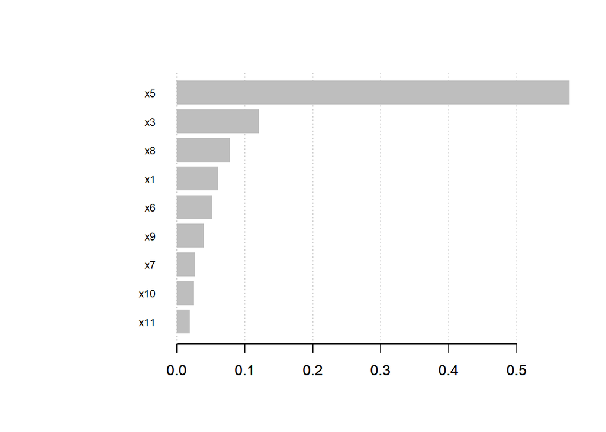

```r
xgb.importance(model = new_data_xgb) %>%
  xgb.plot.importance(top_n = 11)
```

#### use Gain to Variable Selection

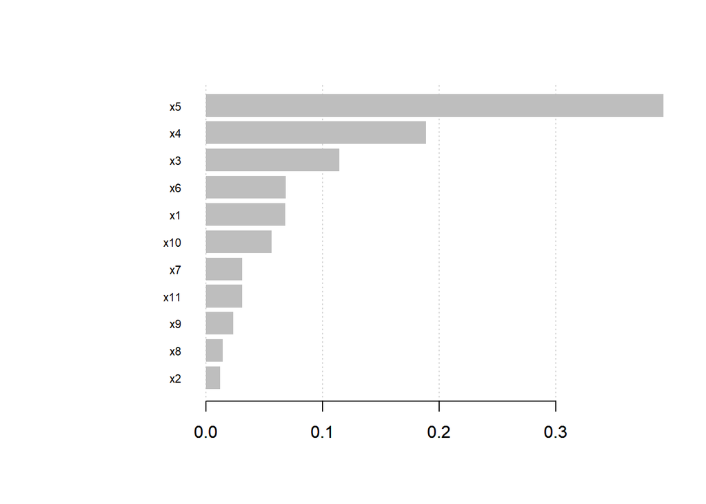

```r
xgb_test <- xgboost(data = data.matrix(sim[,-1]),
label = sim[,"y"],
eta = 0.5,
max_depth = 10,
nround=25,
subsample = 0.7,
colsample_bytree = 0.7,
objective = "reg:squarederror",
verbose = 0
)

xgb.importance(model = xgb_test) %>%
  xgb.plot.importance(top_n = 11)
```

```r
md <- formula(y~x1+x3+x4+x5+x6+x7+x9+x10+x11)
VS <- c(1,3,4,5,6,7,9,10,11)+1
```

##### old data

###### regression

```r
old_data_lm <- lm(md,data = sim)



old_data_lm %>% summary()
```

```
##
## Call:
## lm(formula = md, data = sim)
##
## Residuals:
##      Min       1Q   Median       3Q      Max
## -14.9415  -3.1495   0.5623   3.6158  14.0541
##
## Coefficients:
##             Estimate Std. Error t value Pr(>|t|)
## (Intercept)  -0.3985     0.5787  -0.689    0.493
## x1           13.2074     0.5062  26.093  < 2e-16 ***
## x3           -1.8068     0.3090  -5.846 7.96e-08 ***
## x4            0.3360     0.2809   1.196    0.235
## x5            9.4801     0.3598  26.351  < 2e-16 ***
## x6           10.2742     0.6330  16.232  < 2e-16 ***
## x7            4.5202     0.5875   7.695 1.73e-11 ***
## x9            4.3182     0.5989   7.210 1.68e-10 ***
## x10           8.4684     0.5723  14.798  < 2e-16 ***
## x11          -0.4208     0.5647  -0.745    0.458
## ---
## Signif. codes:  0 '***' 0.001 '**' 0.01 '*' 0.05 '.' 0.1 ' ' 1
##
## Residual standard error: 5.629 on 90 degrees of freedom
## Multiple R-squared:  0.9809, Adjusted R-squared:  0.9789
## F-statistic: 512.2 on 9 and 90 DF,  p-value: < 2.2e-16
```

```r
print("train MSE")
```

```
## [1] "train MSE"
```

```r
label  <- old_data_lm %>% predict(sim)
mean((sim$y-label)^2)
```

```
## [1] 28.51782
```

```r
print("test MSE")
```

```
## [1] "test MSE"
```

```r
label  <- old_data_lm %>% predict(sim_3)
mean((sim_3$y-label)^2)
```

```
## [1] 36.95225
```

###### XGboost

```r
old_data_xgb <- xgboost(data = data.matrix(sim[,VS]),
label = sim[,"y"],
eta = 0.5,
max_depth = 10,
nround=25,
subsample = 0.7,
colsample_bytree = 0.7,
objective = "reg:squarederror",
verbose = 0
)
print("train MSE")
```

```
## [1] "train MSE"
```

```r
label  <- predict(old_data_xgb,xgb.DMatrix(data.matrix(sim[,VS])))
mean((sim$y-label)^2)
```

```
## [1] 0.006234547
```

```r
print("test MSE")
```

```
## [1] "test MSE"
```

```r
label  <- predict(old_data_xgb,xgb.DMatrix(data.matrix(sim_3[,VS])))
mean((sim_3$y-label)^2)
```

```
## [1] 461.8528
```

```r
xgb.importance(model = old_data_xgb)
```

| Feature | Gain | Cover | Frequency |
| --- | --- | --- | --- |
| x5 | 0.386440148 | 0.13306416 | 0.09684947 |
| x4 | 0.217536455 | 0.08198016 | 0.09451575 |
| x1 | 0.156806211 | 0.18967787 | 0.28938156 |
| x6 | 0.099783202 | 0.10752216 | 0.07351225 |
| x10 | 0.053323464 | 0.12823664 | 0.09334889 |
| x11 | 0.036030582 | 0.06363557 | 0.05717620 |
| x3 | 0.023652676 | 0.14342140 | 0.16102684 |
| x9 | 0.017630243 | 0.05608707 | 0.05717620 |
| x7 | 0.008797019 | 0.09637497 | 0.07701284 |

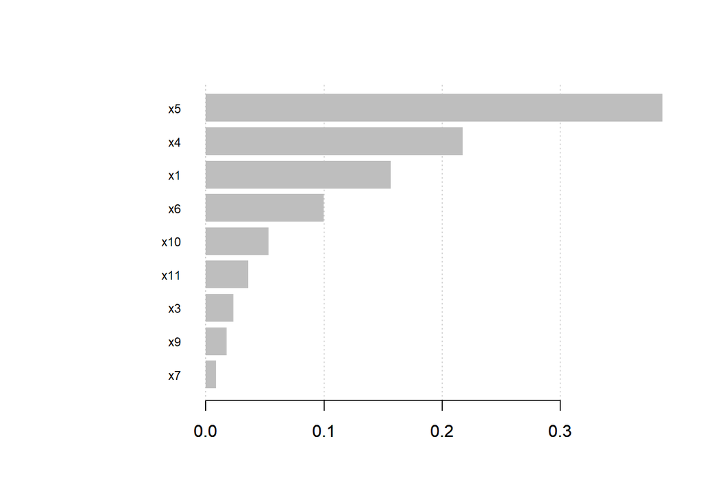

```r
xgb.importance(model = old_data_xgb) %>%
  xgb.plot.importance(top_n = 11)
```

##### new data

###### regression

```r
new_data_lm <- lm(md,data = sim_2)



new_data_lm %>% summary()
```

```
##
## Call:
## lm(formula = md, data = sim_2)
##
## Residuals:
##      Min       1Q   Median       3Q      Max
## -13.2539  -2.9705   0.3972   3.2421   9.8357
##
## Coefficients:
##             Estimate Std. Error t value Pr(>|t|)
## (Intercept) -0.42609    0.49527  -0.860    0.392
## x1          12.93389    0.44883  28.817  < 2e-16 ***
## x3          -1.11635    0.26569  -4.202 6.23e-05 ***
## x4           0.09303    0.21403   0.435    0.665
## x5          10.16355    0.30649  33.161  < 2e-16 ***
## x6          10.79434    0.47176  22.881  < 2e-16 ***
## x7           5.17983    0.49213  10.525  < 2e-16 ***
## x9           4.24902    0.48821   8.703 1.43e-13 ***
## x10          7.60970    0.47709  15.950  < 2e-16 ***
## x11         -0.11441    0.48269  -0.237    0.813
## ---
## Signif. codes:  0 '***' 0.001 '**' 0.01 '*' 0.05 '.' 0.1 ' ' 1
##
## Residual standard error: 4.772 on 90 degrees of freedom
## Multiple R-squared:  0.9837, Adjusted R-squared:  0.9821
## F-statistic: 604.1 on 9 and 90 DF,  p-value: < 2.2e-16
```

```r
print("train MSE")
```

```
## [1] "train MSE"
```

```r
label  <- new_data_lm %>% predict(sim_2)
mean((sim_2$y-label)^2)
```

```
## [1] 20.49726
```

```r
print("test MSE")
```

```
## [1] "test MSE"
```

```r
label  <- new_data_lm %>% predict(sim_3)
mean((sim_3$y-label)^2)
```

```
## [1] 34.81082
```

###### XGboost

```r
new_data_xgb <- xgboost(data = data.matrix(sim_2[,VS]),
label = sim_2[,"y"],
eta = 0.5,
max_depth = 10,
nround=25,
subsample = 0.7,
colsample_bytree = 0.7,
objective = "reg:squarederror",
verbose = 0
)
print("train MSE")
```

```
## [1] "train MSE"
```

```r
label  <- predict(new_data_xgb,xgb.DMatrix(data.matrix(sim_2[,VS])))
mean((sim_2$y-label)^2)
```

```
## [1] 0.0162474
```

```r
print("test MSE")
```

```
## [1] "test MSE"
```

```r
label  <- predict(new_data_xgb,xgb.DMatrix(data.matrix(sim_3[,VS])))
mean((sim_3$y-label)^2)
```

```
## [1] 565.2275
```

```r
xgb.importance(model = new_data_xgb)
```

| Feature | Gain | Cover | Frequency |
| --- | --- | --- | --- |
| x4 | 0.29655057 | 0.07954636 | 0.09090909 |
| x5 | 0.24794263 | 0.15725581 | 0.12345679 |
| x1 | 0.19760955 | 0.16851689 | 0.21885522 |
| x7 | 0.10578702 | 0.12171552 | 0.11896745 |
| x3 | 0.04757010 | 0.09879403 | 0.15937149 |
| x6 | 0.04742429 | 0.05542688 | 0.06060606 |
| x9 | 0.03318020 | 0.10741954 | 0.07968575 |
| x10 | 0.01265898 | 0.13976519 | 0.09652076 |
| x11 | 0.01127666 | 0.07155978 | 0.05162738 |

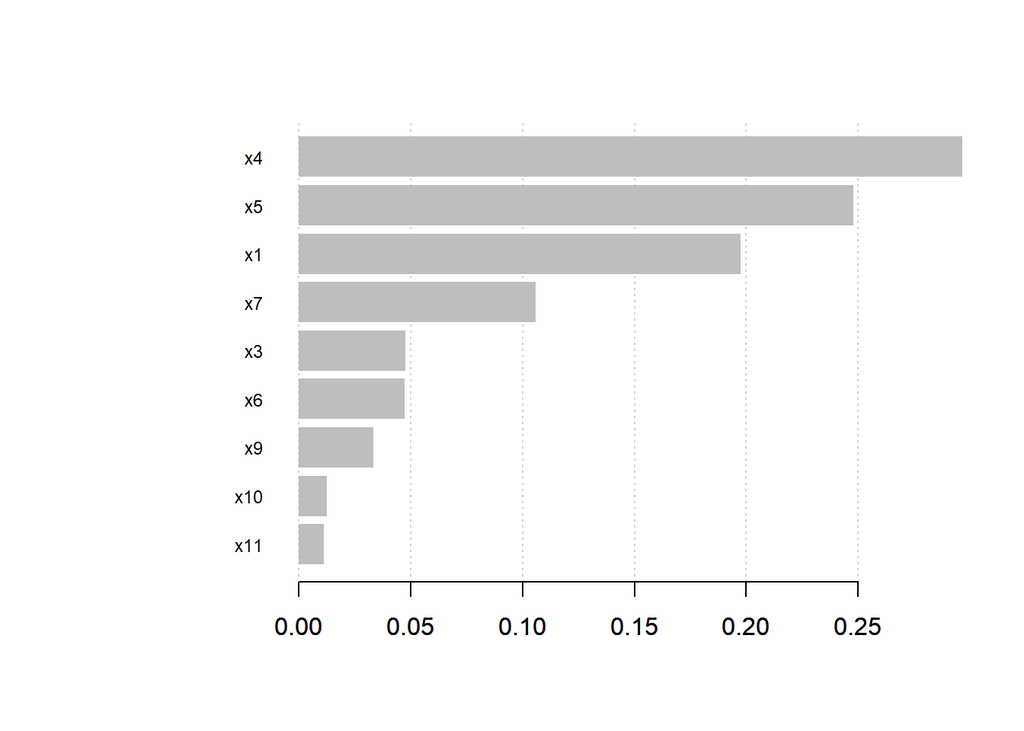

```r
xgb.importance(model = new_data_xgb) %>%
  xgb.plot.importance(top_n = 11)
```

## 資料二(一般項加交互作用項)

regression的表現比資料一差。  
XGboost還是差不多。

$x_{1 \sim 10}\sim MN(\mu , \Sigma )$ $\mu=(0,0,0,0,0,0,0,0,0,0)$
$$\Sigma = \begin{pmatrix}
1 & 0 & 0 & 0 & 0 & 0 & 0 & 0 & 0 & 0\\
0 & 1& 0 & 0 & 0 & 0 & 0 & 0 & 0 & 0\\
0 & 0& 1 & 0 & 0 & 0 & 0 & 0 & 0 & 0\\
0 & 0& 0 & 1 & 0 & 0 & 0 & 0 & 0 & 0\\
0 & 0& 0 & 0 & 1 & 0 & 0 & 0 & 0 & 0\\
0 & 0& 0 & 0 & 0 & 1 & 0 & 0 & 0 & 0\\
0 & 0& 0 & 0 & 0 & 0 & 1 & 0 & 0 & 0\\
0 & 0& 0 & 0 & 0 & 0 & 0 & 1 & 0 & 0\\
0 & 0& 0 & 0 & 0 & 0 & 0 & 0 & 1 & 0\\
0 & 0& 0 & 0 & 0 & 0 & 0 & 0 & 0 & 1
\end{pmatrix}$$

$x_{11} \sim N(0,1)$

$y=10x_1+5x_2-3x_3+4x_4+8x_5-7x_6+9x_7-2x_8+5x_9-4x_{10}+10x_1x_2-7x_3x_4+\epsilon$

$\epsilon \sim N(0,4)$

### 第一次

```r
set.seed(1423)
x <- rmvnorm(n = 100,mean = c(0,0,0,0,0,0,0,0,0,0),sigma = diag(1,10))
set.seed(597)
x_11 <- rnorm(n = 100)
set.seed(55)
sd <- rnorm(100,sd = 4)
y <- 10*x[,1]+5*x[,2]-3*x[,3]+4*x[,4]+8*x[,5]-7*x[,6]+9*x[,7]-2*x[,8]+5*x[,9]-4*x[,10]+10*x[,1]*x[,2]-7*x[,3]*x[,4]+sd
sim <- data.frame(y,x,x_11)


set.seed(1232)
x <- rmvnorm(n = 100,mean = c(0,0,0,0,0,0,0,0,0,0),sigma = diag(1,10))
set.seed(599)
x_11 <- rnorm(n = 100)
set.seed(57)
sd <- rnorm(100,sd = 4)
y <- 10*x[,1]+5*x[,2]-3*x[,3]+4*x[,4]+8*x[,5]-7*x[,6]+9*x[,7]-2*x[,8]+5*x[,9]-4*x[,10]+10*x[,1]*x[,2]-7*x[,3]*x[,4]+sd
sim_2 <- data.frame(y,x,x_11)


set.seed(125332)
x <- rmvnorm(n = 100,mean = c(0,0,0,0,0,0,0,0,0,0),sigma = diag(1,10))
set.seed(56699)
x_11 <- rnorm(n = 100)
set.seed(5247)
sd <- rnorm(100,sd = 4)
y <- 10*x[,1]+5*x[,2]-3*x[,3]+4*x[,4]+8*x[,5]-7*x[,6]+9*x[,7]-2*x[,8]+5*x[,9]-4*x[,10]+10*x[,1]*x[,2]-7*x[,3]*x[,4]+sd
sim_3 <- data.frame(y,x,x_11)





names(sim) <- c("y",paste0("x",1:11))
names(sim_2) <- c("y",paste0("x",1:11))
names(sim_3) <- c("y",paste0("x",1:11))
```

#### use p-value to Variable Selection

```r
(old_data_lm <- lm(y~.,data = sim) %>% ols_step_forward_p())
```

```
##
##                              Selection Summary
## ---------------------------------------------------------------------------
##         Variable                  Adj.
## Step    Entered     R-Square    R-Square      C(p)        AIC        RMSE
## ---------------------------------------------------------------------------
##    1    x7            0.1693      0.1609    178.3475    893.5113    20.6707
##    2    x1            0.3033      0.2889    136.1076    877.9264    19.0282
##    3    x2            0.4173      0.3991    100.4503    862.0555    17.4921
##    4    x9            0.5010      0.4800     74.8201    848.5572    16.2728
##    5    x5            0.5602      0.5368     57.2655    837.9280    15.3580
##    6    x6            0.6046      0.5790     44.6060    829.2902    14.6406
##    7    x3            0.6521      0.6256     30.9050    818.4823    13.8068
##    8    x10           0.6963      0.6696     18.3000    806.8883    12.9702
##    9    x4            0.7288      0.7017      9.5683    797.5719    12.3246
## ---------------------------------------------------------------------------
```

```r
md <- formula(y~x1+x2+x3+x4+x5+x6+x7+x9+x10)
VS <- c(1,2,3,4,5,6,7,9,10)+1
```

##### old data

###### regression

```r
old_data_lm$model %>% summary()
```

```
##
## Call:
## lm(formula = paste(response, "~", paste(preds, collapse = " + ")),
##     data = l)
##
## Residuals:
##     Min      1Q  Median      3Q     Max
## -50.976  -5.602   1.421   5.415  28.694
##
## Coefficients:
##             Estimate Std. Error t value Pr(>|t|)
## (Intercept)   -1.253      1.335  -0.939 0.350461
## x7            11.164      1.204   9.271 9.39e-15 ***
## x1            13.137      1.449   9.065 2.52e-14 ***
## x2             7.704      1.283   6.005 3.98e-08 ***
## x9             5.733      1.289   4.446 2.49e-05 ***
## x5             6.381      1.243   5.133 1.63e-06 ***
## x6            -4.966      1.253  -3.963 0.000148 ***
## x3            -5.808      1.411  -4.117 8.49e-05 ***
## x10           -4.613      1.118  -4.126 8.21e-05 ***
## x4             3.724      1.134   3.284 0.001460 **
## ---
## Signif. codes:  0 '***' 0.001 '**' 0.01 '*' 0.05 '.' 0.1 ' ' 1
##
## Residual standard error: 12.32 on 90 degrees of freedom
## Multiple R-squared:  0.7288, Adjusted R-squared:  0.7017
## F-statistic: 26.87 on 9 and 90 DF,  p-value: < 2.2e-16
```

```r
print("train MSE")
```

```
## [1] "train MSE"
```

```r
label  <- old_data_lm$model %>% predict(sim)
mean((sim$y-label)^2)
```

```
## [1] 136.7072
```

```r
print("test MSE")
```

```
## [1] "test MSE"
```

```r
label  <- old_data_lm$model %>% predict(sim_3)
mean((sim_3$y-label)^2)
```

```
## [1] 211.9405
```

###### XGboost

```r
old_data_xgb <- xgboost(data = data.matrix(sim[,VS]),
label = sim[,"y"],
eta = 0.5,
max_depth = 10,
nround=25,
subsample = 0.7,
colsample_bytree = 0.7,
objective = "reg:squarederror",
verbose = 0
)
print("train MSE")
```

```
## [1] "train MSE"
```

```r
label  <- predict(old_data_xgb,xgb.DMatrix(data.matrix(sim[,VS])))
mean((sim$y-label)^2)
```

```
## [1] 0.02753398
```

```r
print("test MSE")
```

```
## [1] "test MSE"
```

```r
label  <- predict(old_data_xgb,xgb.DMatrix(data.matrix(sim_3[,VS])))
mean((sim_3$y-label)^2)
```

```
## [1] 445.1453
```

```r
xgb.importance(model = old_data_xgb)
```

| Feature | Gain | Cover | Frequency |
| --- | --- | --- | --- |
| x7 | 0.19713343 | 0.09903917 | 0.08354430 |
| x2 | 0.14789399 | 0.24353289 | 0.22658228 |
| x9 | 0.14515938 | 0.06585366 | 0.05443038 |
| x4 | 0.11545352 | 0.05898004 | 0.08860759 |
| x1 | 0.11443638 | 0.15262380 | 0.22784810 |
| x6 | 0.10819313 | 0.09741316 | 0.08101266 |
| x5 | 0.07662214 | 0.07050998 | 0.08734177 |
| x10 | 0.06266442 | 0.09963045 | 0.06582278 |
| x3 | 0.03244360 | 0.11241685 | 0.08481013 |

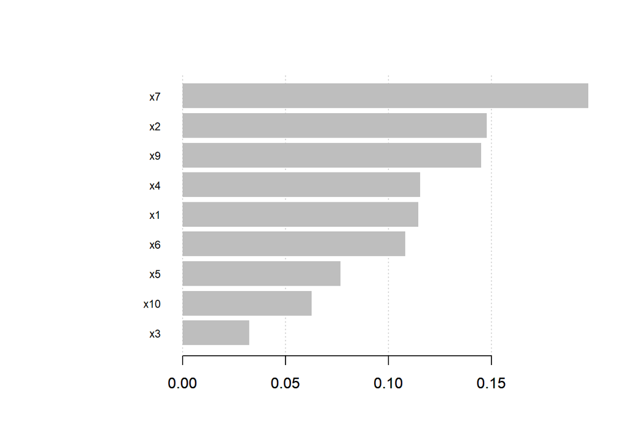

```r
xgb.importance(model = old_data_xgb) %>%
  xgb.plot.importance(top_n = 11)
```

##### new data

###### regression

```r
new_data_lm <- lm(md,data = sim_2)



new_data_lm %>% summary()
```

```
##
## Call:
## lm(formula = md, data = sim_2)
##
## Residuals:
##     Min      1Q  Median      3Q     Max
## -40.368  -5.606  -0.538   8.070  29.931
##
## Coefficients:
##             Estimate Std. Error t value Pr(>|t|)
## (Intercept)  -0.5793     1.3675  -0.424 0.672875
## x1           10.5581     1.3512   7.814 9.83e-12 ***
## x2            5.6832     1.2530   4.536 1.76e-05 ***
## x3           -1.8617     1.3784  -1.351 0.180193
## x4            2.1289     1.3902   1.531 0.129190
## x5            7.0473     1.3596   5.183 1.33e-06 ***
## x6           -7.9515     1.5106  -5.264 9.52e-07 ***
## x7           10.3659     1.4786   7.011 4.22e-10 ***
## x9            5.0384     1.3193   3.819 0.000246 ***
## x10          -3.1670     1.2664  -2.501 0.014200 *
## ---
## Signif. codes:  0 '***' 0.001 '**' 0.01 '*' 0.05 '.' 0.1 ' ' 1
##
## Residual standard error: 12.92 on 90 degrees of freedom
## Multiple R-squared:  0.7226, Adjusted R-squared:  0.6948
## F-statistic: 26.04 on 9 and 90 DF,  p-value: < 2.2e-16
```

```r
print("train MSE")
```

```
## [1] "train MSE"
```

```r
label  <- new_data_lm %>% predict(sim_2)
mean((sim_2$y-label)^2)
```

```
## [1] 150.1239
```

```r
print("test MSE")
```

```
## [1] "test MSE"
```

```r
label  <- new_data_lm %>% predict(sim_3)
mean((sim_3$y-label)^2)
```

```
## [1] 179.2459
```

###### XGboost

```r
new_data_xgb <- xgboost(data = data.matrix(sim_2[,VS]),
label = sim_2[,"y"],
eta = 0.5,
max_depth = 10,
nround=25,
subsample = 0.7,
colsample_bytree = 0.7,
objective = "reg:squarederror",
verbose = 0
)
print("train MSE")
```

```
## [1] "train MSE"
```

```r
label  <- predict(new_data_xgb,xgb.DMatrix(data.matrix(sim_2[,VS])))
mean((sim_2$y-label)^2)
```

```
## [1] 0.005665071
```

```r
print("test MSE")
```

```
## [1] "test MSE"
```

```r
label  <- predict(new_data_xgb,xgb.DMatrix(data.matrix(sim_3[,VS])))
mean((sim_3$y-label)^2)
```

```
## [1] 260.7021
```

```r
xgb.importance(model = new_data_xgb)
```

| Feature | Gain | Cover | Frequency |
| --- | --- | --- | --- |
| x1 | 0.33954825 | 0.17652359 | 0.27468785 |
| x7 | 0.15423702 | 0.14302097 | 0.08059024 |
| x2 | 0.15388527 | 0.13016055 | 0.14755959 |
| x5 | 0.12506253 | 0.08764744 | 0.08286039 |
| x4 | 0.08606617 | 0.10566841 | 0.11464245 |
| x9 | 0.04789025 | 0.09542923 | 0.06242906 |
| x6 | 0.04541769 | 0.11082896 | 0.07945516 |
| x10 | 0.02793888 | 0.05471822 | 0.04767310 |
| x3 | 0.01995395 | 0.09600262 | 0.11010216 |

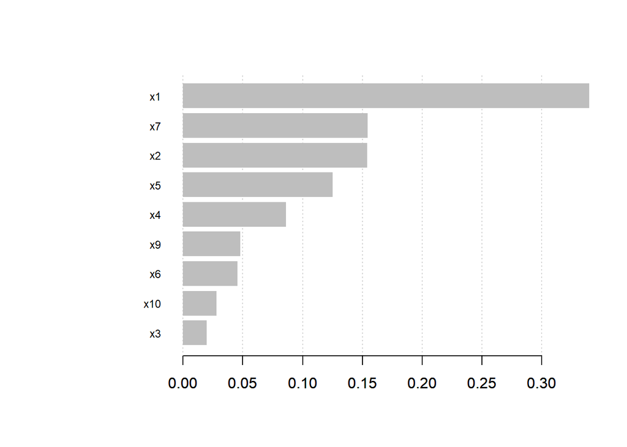

```r
xgb.importance(model = new_data_xgb) %>%
  xgb.plot.importance(top_n = 11)
```

#### use Gain to Variable Selection

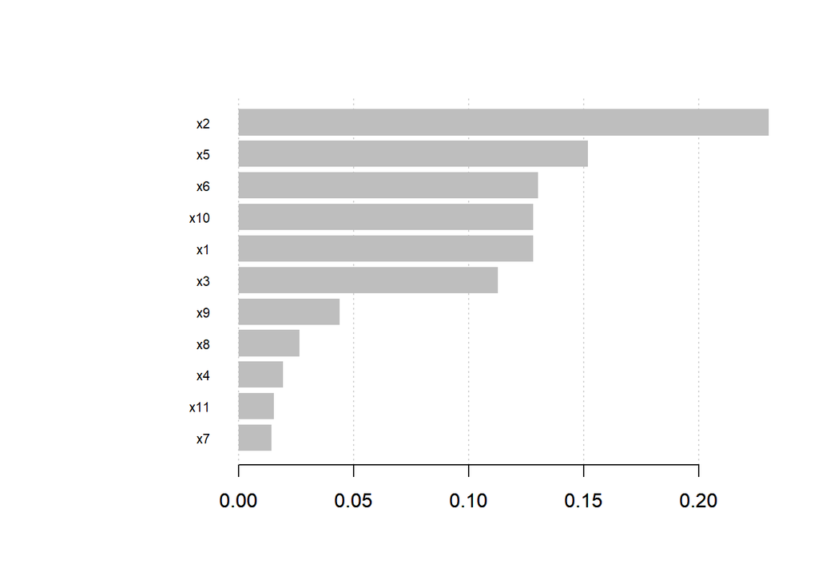

```r
xgb_test <- xgboost(data = data.matrix(sim[,-1]),
label = sim[,"y"],
eta = 0.5,
max_depth = 10,
nround=25,
subsample = 0.7,
colsample_bytree = 0.7,
objective = "reg:squarederror",
verbose = 0
)

xgb.importance(model = xgb_test) %>%
  xgb.plot.importance(top_n = 11)
```

```r
md <- formula(y~x1+x2+x3+x5+x6+x7+x8+x9+x10)
VS <- c(1,2,3,4,5,6,7,8,9,10)+1
```

##### old data

###### regression

```r
old_data_lm <- lm(md,data = sim)



old_data_lm %>% summary()
```

```
##
## Call:
## lm(formula = md, data = sim)
##
## Residuals:
##     Min      1Q  Median      3Q     Max
## -49.941  -5.133   0.915   6.191  33.721
##
## Coefficients:
##             Estimate Std. Error t value Pr(>|t|)
## (Intercept)  -0.5830     1.3937  -0.418 0.676713
## x1           12.7557     1.5391   8.288 1.04e-12 ***
## x2            7.7084     1.3620   5.660 1.78e-07 ***
## x3           -5.5050     1.4896  -3.696 0.000376 ***
## x5            6.3289     1.3114   4.826 5.66e-06 ***
## x6           -5.4641     1.3192  -4.142 7.76e-05 ***
## x7           11.2924     1.2713   8.883 6.04e-14 ***
## x8           -0.9612     1.2450  -0.772 0.442125
## x9            6.0153     1.3636   4.411 2.84e-05 ***
## x10          -4.3036     1.1750  -3.663 0.000421 ***
## ---
## Signif. codes:  0 '***' 0.001 '**' 0.01 '*' 0.05 '.' 0.1 ' ' 1
##
## Residual standard error: 13 on 90 degrees of freedom
## Multiple R-squared:  0.6983, Adjusted R-squared:  0.6681
## F-statistic: 23.15 on 9 and 90 DF,  p-value: < 2.2e-16
```

```r
print("train MSE")
```

```
## [1] "train MSE"
```

```r
label  <- old_data_lm %>% predict(sim)
mean((sim$y-label)^2)
```

```
## [1] 152.0798
```

```r
print("test MSE")
```

```
## [1] "test MSE"
```

```r
label  <- old_data_lm %>% predict(sim_3)
mean((sim_3$y-label)^2)
```

```
## [1] 202.35
```

###### XGboost

```r
old_data_xgb <- xgboost(data = data.matrix(sim[,VS]),
label = sim[,"y"],
eta = 0.5,
max_depth = 10,
nround=25,
subsample = 0.7,
colsample_bytree = 0.7,
objective = "reg:squarederror",
verbose = 0
)
print("train MSE")
```

```
## [1] "train MSE"
```

```r
label  <- predict(old_data_xgb,xgb.DMatrix(data.matrix(sim[,VS])))
mean((sim$y-label)^2)
```

```
## [1] 0.05709177
```

```r
print("test MSE")
```

```
## [1] "test MSE"
```

```r
label  <- predict(old_data_xgb,xgb.DMatrix(data.matrix(sim_3[,VS])))
mean((sim_3$y-label)^2)
```

```
## [1] 375.7546
```

```r
xgb.importance(model = old_data_xgb)
```

| Feature | Gain | Cover | Frequency |
| --- | --- | --- | --- |
| x7 | 0.23575213 | 0.08857640 | 0.08957219 |
| x2 | 0.18430605 | 0.19853581 | 0.20989305 |
| x1 | 0.15383425 | 0.16801972 | 0.19385027 |
| x9 | 0.15309204 | 0.04841983 | 0.03877005 |
| x10 | 0.07184170 | 0.13532908 | 0.07085561 |
| x5 | 0.06842456 | 0.08937373 | 0.08422460 |
| x4 | 0.06625772 | 0.06443897 | 0.08689840 |
| x3 | 0.02565899 | 0.04573790 | 0.07620321 |
| x6 | 0.02194220 | 0.07748623 | 0.07486631 |
| x8 | 0.01889038 | 0.08408234 | 0.07486631 |

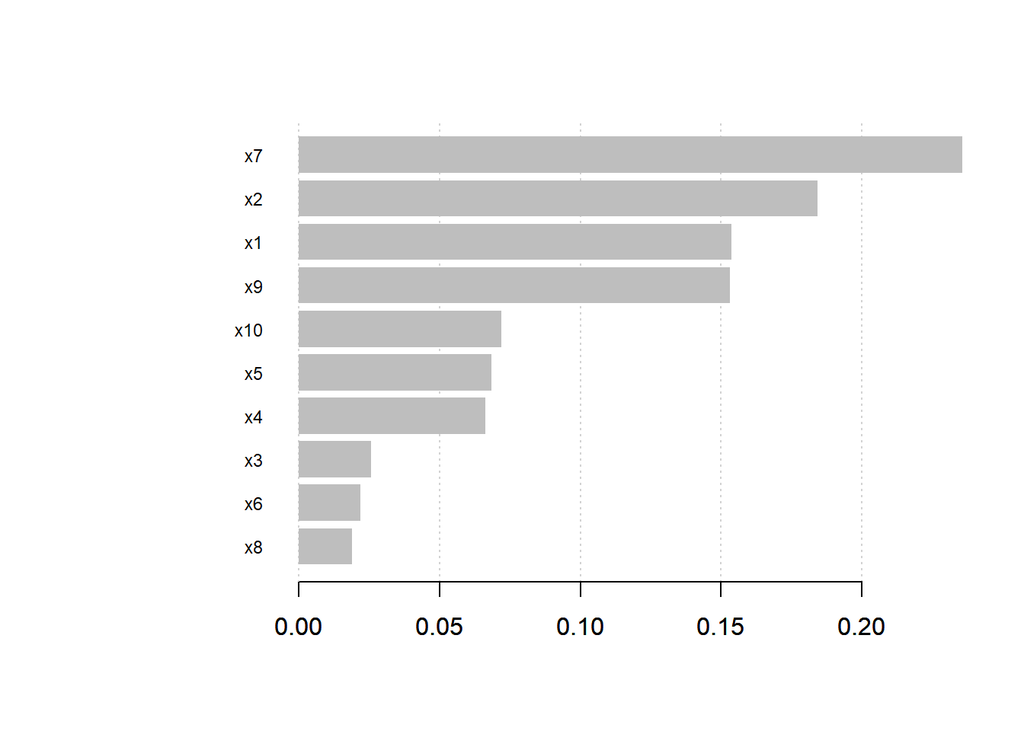

```r
xgb.importance(model = old_data_xgb) %>%
  xgb.plot.importance(top_n = 11)
```

##### new data

###### regression

```r
new_data_lm <- lm(md,data = sim_2)



new_data_lm %>% summary()
```

```
##
## Call:
## lm(formula = md, data = sim_2)
##
## Residuals:
##     Min      1Q  Median      3Q     Max
## -38.986  -5.551  -0.409   6.994  31.204
##
## Coefficients:
##             Estimate Std. Error t value Pr(>|t|)
## (Intercept)  -0.1808     1.4075  -0.128 0.898086
## x1           10.4839     1.3606   7.705 1.64e-11 ***
## x2            5.5964     1.2695   4.408 2.87e-05 ***
## x3           -1.6576     1.3796  -1.201 0.232711
## x5            7.1752     1.3657   5.254 9.91e-07 ***
## x6           -7.6687     1.5220  -5.039 2.40e-06 ***
## x7           10.0490     1.4843   6.770 1.28e-09 ***
## x8           -1.3534     1.3683  -0.989 0.325255
## x9            5.2665     1.3273   3.968 0.000145 ***
## x10          -3.0021     1.2721  -2.360 0.020440 *
## ---
## Signif. codes:  0 '***' 0.001 '**' 0.01 '*' 0.05 '.' 0.1 ' ' 1
##
## Residual standard error: 13.01 on 90 degrees of freedom
## Multiple R-squared:  0.7184, Adjusted R-squared:  0.6902
## F-statistic: 25.51 on 9 and 90 DF,  p-value: < 2.2e-16
```

```r
print("train MSE")
```

```
## [1] "train MSE"
```

```r
label  <- new_data_lm %>% predict(sim_2)
mean((sim_2$y-label)^2)
```

```
## [1] 152.3791
```

```r
print("test MSE")
```

```
## [1] "test MSE"
```

```r
label  <- new_data_lm %>% predict(sim_3)
mean((sim_3$y-label)^2)
```

```
## [1] 177.8968
```

###### XGboost

```r
new_data_xgb <- xgboost(data = data.matrix(sim_2[,VS]),
label = sim_2[,"y"],
eta = 0.5,
max_depth = 10,
nround=25,
subsample = 0.7,
colsample_bytree = 0.7,
objective = "reg:squarederror",
verbose = 0
)
print("train MSE")
```

```
## [1] "train MSE"
```

```r
label  <- predict(new_data_xgb,xgb.DMatrix(data.matrix(sim_2[,VS])))
mean((sim_2$y-label)^2)
```

```
## [1] 0.01133457
```

```r
print("test MSE")
```

```
## [1] "test MSE"
```

```r
label  <- predict(new_data_xgb,xgb.DMatrix(data.matrix(sim_3[,VS])))
mean((sim_3$y-label)^2)
```

```
## [1] 294.2058
```

```r
xgb.importance(model = new_data_xgb)
```

| Feature | Gain | Cover | Frequency |
| --- | --- | --- | --- |
| x1 | 0.395743925 | 0.15096824 | 0.25660377 |
| x2 | 0.133318477 | 0.12594888 | 0.14591195 |
| x5 | 0.098328577 | 0.09628195 | 0.07547170 |
| x6 | 0.082470327 | 0.10263362 | 0.07547170 |
| x10 | 0.080899551 | 0.07126259 | 0.06540881 |
| x7 | 0.076652618 | 0.11913246 | 0.07421384 |
| x9 | 0.048167843 | 0.05158792 | 0.05283019 |
| x3 | 0.045956437 | 0.17784663 | 0.13836478 |
| x4 | 0.032222057 | 0.04399690 | 0.05786164 |
| x8 | 0.006240189 | 0.06034082 | 0.05786164 |

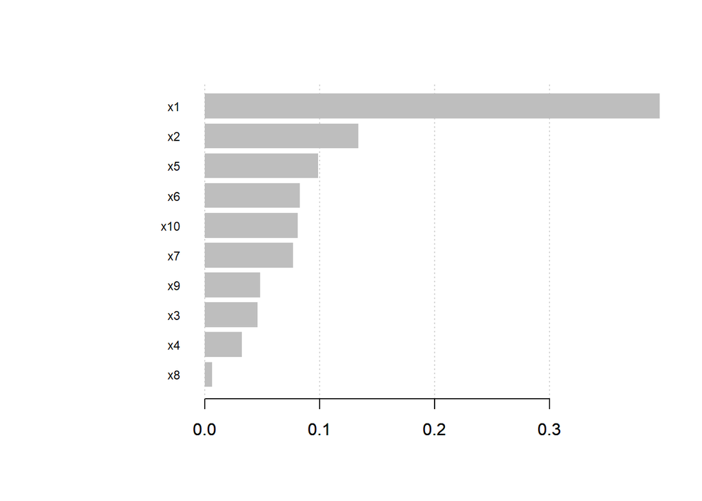

```r
xgb.importance(model = new_data_xgb) %>%
  xgb.plot.importance(top_n = 11)
```

### 第二次

```r
set.seed(17423)
x <- rmvnorm(n = 100,mean = c(0,0,0,0,0,0,0,0,0,0),sigma = diag(1,10))
set.seed(5997)
x_11 <- rnorm(n = 100)
set.seed(515)
sd <- rnorm(100,sd = 4)
y <- 10*x[,1]+5*x[,2]-3*x[,3]+4*x[,4]+8*x[,5]-7*x[,6]+9*x[,7]-2*x[,8]+5*x[,9]-4*x[,10]+10*x[,1]*x[,2]-7*x[,3]*x[,4]+sd
sim <- data.frame(y,x,x_11)


set.seed(12632)
x <- rmvnorm(n = 100,mean = c(0,0,0,0,0,0,0,0,0,0),sigma = diag(1,10))
set.seed(5998)
x_11 <- rnorm(n = 100)
set.seed(597)
sd <- rnorm(100,sd = 4)
y <- 10*x[,1]+5*x[,2]-3*x[,3]+4*x[,4]+8*x[,5]-7*x[,6]+9*x[,7]-2*x[,8]+5*x[,9]-4*x[,10]+10*x[,1]*x[,2]-7*x[,3]*x[,4]+sd
sim_2 <- data.frame(y,x,x_11)


set.seed(18332)
x <- rmvnorm(n = 100,mean = c(0,0,0,0,0,0,0,0,0,0),sigma = diag(1,10))
set.seed(56499)
x_11 <- rnorm(n = 100)
set.seed(517)
sd <- rnorm(100,sd = 4)
y <- 10*x[,1]+5*x[,2]-3*x[,3]+4*x[,4]+8*x[,5]-7*x[,6]+9*x[,7]-2*x[,8]+5*x[,9]-4*x[,10]+10*x[,1]*x[,2]-7*x[,3]*x[,4]+sd
sim_3 <- data.frame(y,x,x_11)





names(sim) <- c("y",paste0("x",1:11))
names(sim_2) <- c("y",paste0("x",1:11))
names(sim_3) <- c("y",paste0("x",1:11))
```

#### use p-value to Variable Selection

```r
(old_data_lm <- lm(y~.,data = sim) %>% ols_step_forward_p())
```

```
##
##                              Selection Summary
## ---------------------------------------------------------------------------
##         Variable                  Adj.
## Step    Entered     R-Square    R-Square      C(p)        AIC        RMSE
## ---------------------------------------------------------------------------
##    1    x1            0.3338      0.3270    169.6107    878.2052    19.1478
##    2    x7            0.4503      0.4390    125.1517    860.9785    17.4822
##    3    x5            0.5784      0.5652     76.0930    836.4538    15.3904
##    4    x6            0.6299      0.6143     57.5638    825.4281    14.4957
##    5    x9            0.7016      0.6857     30.9825    805.8997    13.0854
##    6    x2            0.7336      0.7165     20.1911    796.5260    12.4283
##    7    x4            0.7544      0.7357     13.9172    790.4142    11.9990
##    8    x10           0.7740      0.7541      8.1167    784.1126    11.5742
## ---------------------------------------------------------------------------
```

```r
md <- formula(y~x1+x2+x4+x5+x6+x7+x9+x10)
VS <- c(1,2,4,5,6,7,9,10)+1
```

##### old data

###### regression

```r
old_data_lm$model %>% summary()
```

```
##
## Call:
## lm(formula = paste(response, "~", paste(preds, collapse = " + ")),
##     data = l)
##
## Residuals:
##     Min      1Q  Median      3Q     Max
## -35.524  -7.171   0.463   8.339  31.349
##
## Coefficients:
##             Estimate Std. Error t value Pr(>|t|)
## (Intercept)  -0.2577     1.1766  -0.219 0.827132
## x1           12.6142     1.2194  10.345  < 2e-16 ***
## x7            8.4138     1.0973   7.667 1.86e-11 ***
## x5            6.5554     1.1718   5.595 2.31e-07 ***
## x6           -6.3724     1.2415  -5.133 1.61e-06 ***
## x9            6.8011     1.2093   5.624 2.03e-07 ***
## x2            5.0421     1.2762   3.951 0.000153 ***
## x4            3.5658     1.1580   3.079 0.002744 **
## x10          -3.4160     1.2171  -2.807 0.006124 **
## ---
## Signif. codes:  0 '***' 0.001 '**' 0.01 '*' 0.05 '.' 0.1 ' ' 1
##
## Residual standard error: 11.57 on 91 degrees of freedom
## Multiple R-squared:  0.774,  Adjusted R-squared:  0.7541
## F-statistic: 38.95 on 8 and 91 DF,  p-value: < 2.2e-16
```

```r
print("train MSE")
```

```
## [1] "train MSE"
```

```r
label  <- old_data_lm$model %>% predict(sim)
mean((sim$y-label)^2)
```

```
## [1] 121.9058
```

```r
print("test MSE")
```

```
## [1] "test MSE"
```

```r
label  <- old_data_lm$model %>% predict(sim_3)
mean((sim_3$y-label)^2)
```

```
## [1] 210.349
```

###### XGboost

```r
old_data_xgb <- xgboost(data = data.matrix(sim[,VS]),
label = sim[,"y"],
eta = 0.5,
max_depth = 10,
nround=25,
subsample = 0.7,
colsample_bytree = 0.7,
objective = "reg:squarederror",
verbose = 0
)
print("train MSE")
```

```
## [1] "train MSE"
```

```r
label  <- predict(old_data_xgb,xgb.DMatrix(data.matrix(sim[,VS])))
mean((sim$y-label)^2)
```

```
## [1] 0.02004396
```

```r
print("test MSE")
```

```
## [1] "test MSE"
```

```r
label  <- predict(old_data_xgb,xgb.DMatrix(data.matrix(sim_3[,VS])))
mean((sim_3$y-label)^2)
```

```
## [1] 398.9504
```

```r
xgb.importance(model = old_data_xgb)
```

| Feature | Gain | Cover | Frequency |
| --- | --- | --- | --- |
| x1 | 0.37876883 | 0.20863147 | 0.27272727 |
| x2 | 0.12136870 | 0.14498757 | 0.19580420 |
| x5 | 0.12110273 | 0.09844091 | 0.09790210 |
| x6 | 0.10966985 | 0.07117572 | 0.07459207 |
| x4 | 0.09284831 | 0.11779770 | 0.10955711 |
| x7 | 0.09175701 | 0.11576410 | 0.07692308 |
| x9 | 0.05776896 | 0.13097838 | 0.09090909 |
| x10 | 0.02671562 | 0.11222415 | 0.08158508 |

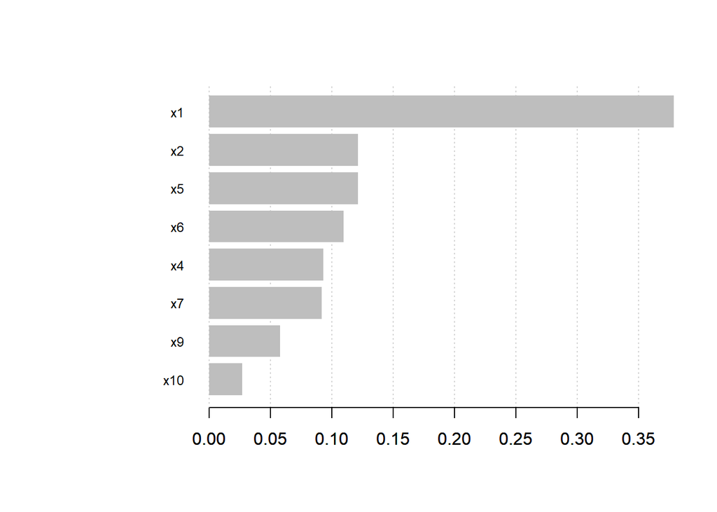

```r
xgb.importance(model = old_data_xgb) %>%
  xgb.plot.importance(top_n = 11)
```

##### new data

###### regression

```r
new_data_lm <- lm(md,data = sim_2)



new_data_lm %>% summary()
```

```
##
## Call:
## lm(formula = md, data = sim_2)
##
## Residuals:
##     Min      1Q  Median      3Q     Max
## -35.843  -7.269   0.131   7.939  30.860
##
## Coefficients:
##             Estimate Std. Error t value Pr(>|t|)
## (Intercept)   0.5373     1.4326   0.375 0.708513
## x1            9.4003     1.3447   6.990 4.44e-10 ***
## x2            5.9590     1.4757   4.038 0.000112 ***
## x4            7.0212     1.4280   4.917 3.88e-06 ***
## x5            4.6080     1.4718   3.131 0.002344 **
## x6           -7.6940     1.3956  -5.513 3.27e-07 ***
## x7            7.4268     1.4738   5.039 2.36e-06 ***
## x9            7.6092     1.4567   5.224 1.10e-06 ***
## x10          -5.1254     1.4718  -3.482 0.000766 ***
## ---
## Signif. codes:  0 '***' 0.001 '**' 0.01 '*' 0.05 '.' 0.1 ' ' 1
##
## Residual standard error: 13.7 on 91 degrees of freedom
## Multiple R-squared:  0.641,  Adjusted R-squared:  0.6094
## F-statistic: 20.31 on 8 and 91 DF,  p-value: < 2.2e-16
```

```r
print("train MSE")
```

```
## [1] "train MSE"
```

```r
label  <- new_data_lm %>% predict(sim_2)
mean((sim_2$y-label)^2)
```

```
## [1] 170.8588
```

```r
print("test MSE")
```

```
## [1] "test MSE"
```

```r
label  <- new_data_lm %>% predict(sim_3)
mean((sim_3$y-label)^2)
```

```
## [1] 216.6385
```

###### XGboost

```r
new_data_xgb <- xgboost(data = data.matrix(sim_2[,VS]),
label = sim_2[,"y"],
eta = 0.5,
max_depth = 10,
nround=25,
subsample = 0.7,
colsample_bytree = 0.7,
objective = "reg:squarederror",
verbose = 0
)
print("train MSE")
```

```
## [1] "train MSE"
```

```r
label  <- predict(new_data_xgb,xgb.DMatrix(data.matrix(sim_2[,VS])))
mean((sim_2$y-label)^2)
```

```
## [1] 0.0165284
```

```r
print("test MSE")
```

```
## [1] "test MSE"
```

```r
label  <- predict(new_data_xgb,xgb.DMatrix(data.matrix(sim_3[,VS])))
mean((sim_3$y-label)^2)
```

```
## [1] 363.247
```

```r
xgb.importance(model = new_data_xgb)
```

| Feature | Gain | Cover | Frequency |
| --- | --- | --- | --- |
| x2 | 0.26125600 | 0.17755212 | 0.22921615 |
| x1 | 0.23920306 | 0.15693515 | 0.21733967 |
| x6 | 0.15349978 | 0.09939226 | 0.08432304 |
| x7 | 0.11813012 | 0.15393492 | 0.08194774 |
| x4 | 0.07785185 | 0.13008693 | 0.12114014 |
| x5 | 0.06851208 | 0.09793061 | 0.11282660 |
| x10 | 0.04873975 | 0.11108547 | 0.08788599 |
| x9 | 0.03280736 | 0.07308254 | 0.06532067 |

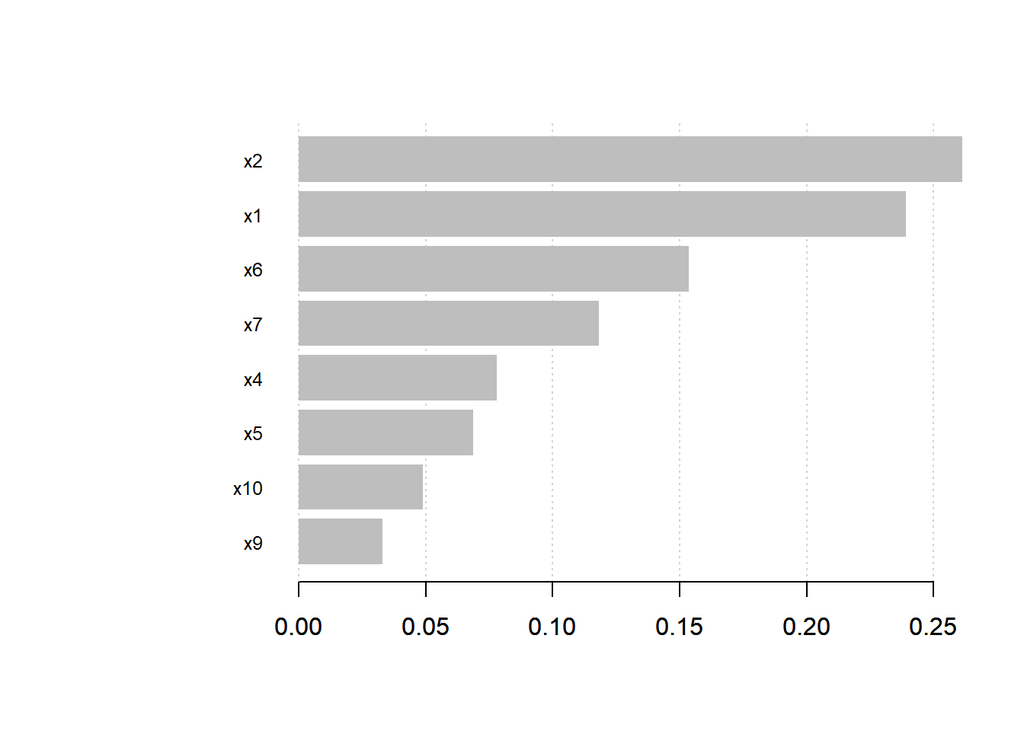

```r
xgb.importance(model = new_data_xgb) %>%
  xgb.plot.importance(top_n = 11)
```

#### use Gain to Variable Selection

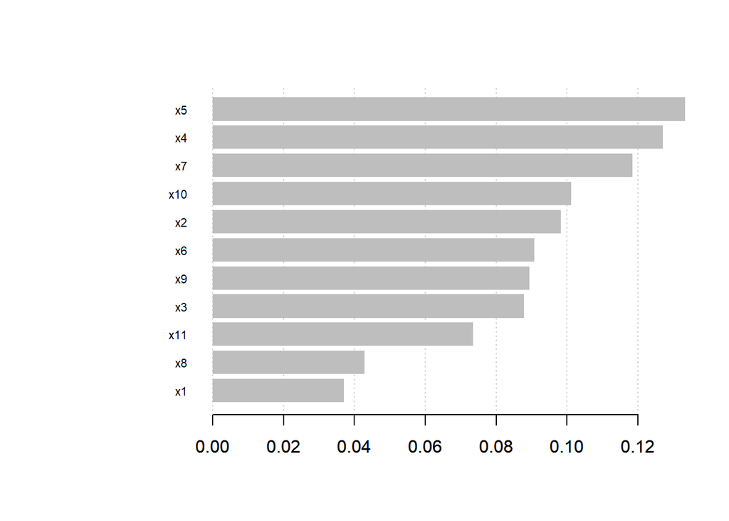

```r
xgb_test <- xgboost(data = data.matrix(sim[,-1]),
label = sim[,"y"],
eta = 0.5,
max_depth = 10,
nround=25,
subsample = 0.7,
colsample_bytree = 0.7,
objective = "reg:squarederror",
verbose = 0
)

xgb.importance(model = xgb_test) %>%
  xgb.plot.importance(top_n = 11)
```

```r
md <- formula(y~x1+x2+x4+x5+x6+x7+x9+x10)
VS <- c(1,2,4,5,6,7,9,10)+1
```

##### old data

###### regression

```r
old_data_lm <- lm(md,data = sim)



old_data_lm %>% summary()
```

```
##
## Call:
## lm(formula = md, data = sim)
##
## Residuals:
##     Min      1Q  Median      3Q     Max
## -35.524  -7.171   0.463   8.339  31.349
##
## Coefficients:
##             Estimate Std. Error t value Pr(>|t|)
## (Intercept)  -0.2577     1.1766  -0.219 0.827132
## x1           12.6142     1.2194  10.345  < 2e-16 ***
## x2            5.0421     1.2762   3.951 0.000153 ***
## x4            3.5658     1.1580   3.079 0.002744 **
## x5            6.5554     1.1718   5.595 2.31e-07 ***
## x6           -6.3724     1.2415  -5.133 1.61e-06 ***
## x7            8.4138     1.0973   7.667 1.86e-11 ***
## x9            6.8011     1.2093   5.624 2.03e-07 ***
## x10          -3.4160     1.2171  -2.807 0.006124 **
## ---
## Signif. codes:  0 '***' 0.001 '**' 0.01 '*' 0.05 '.' 0.1 ' ' 1
##
## Residual standard error: 11.57 on 91 degrees of freedom
## Multiple R-squared:  0.774,  Adjusted R-squared:  0.7541
## F-statistic: 38.95 on 8 and 91 DF,  p-value: < 2.2e-16
```

```r
print("train MSE")
```

```
## [1] "train MSE"
```

```r
label  <- old_data_lm %>% predict(sim)
mean((sim$y-label)^2)
```

```
## [1] 121.9058
```

```r
print("test MSE")
```

```
## [1] "test MSE"
```

```r
label  <- old_data_lm %>% predict(sim_3)
mean((sim_3$y-label)^2)
```

```
## [1] 210.349
```

###### XGboost

```r
old_data_xgb <- xgboost(data = data.matrix(sim[,VS]),
label = sim[,"y"],
eta = 0.5,
max_depth = 10,
nround=25,
subsample = 0.7,
colsample_bytree = 0.7,
objective = "reg:squarederror",
verbose = 0
)
print("train MSE")
```

```
## [1] "train MSE"
```

```r
label  <- predict(old_data_xgb,xgb.DMatrix(data.matrix(sim[,VS])))
mean((sim$y-label)^2)
```

```
## [1] 0.01759512
```

```r
print("test MSE")
```

```
## [1] "test MSE"
```

```r
label  <- predict(old_data_xgb,xgb.DMatrix(data.matrix(sim_3[,VS])))
mean((sim_3$y-label)^2)
```

```
## [1] 332.2935
```

```r
xgb.importance(model = old_data_xgb)
```

| Feature | Gain | Cover | Frequency |
| --- | --- | --- | --- |
| x1 | 0.39356251 | 0.18551966 | 0.24141876 |
| x2 | 0.16536903 | 0.13071234 | 0.19794050 |
| x5 | 0.13075510 | 0.13102374 | 0.10526316 |
| x7 | 0.10496797 | 0.16699105 | 0.11441648 |
| x6 | 0.07064494 | 0.13125730 | 0.10755149 |
| x10 | 0.04809780 | 0.09894901 | 0.07780320 |
| x9 | 0.04419126 | 0.06150253 | 0.03775744 |
| x4 | 0.04241138 | 0.09404438 | 0.11784897 |

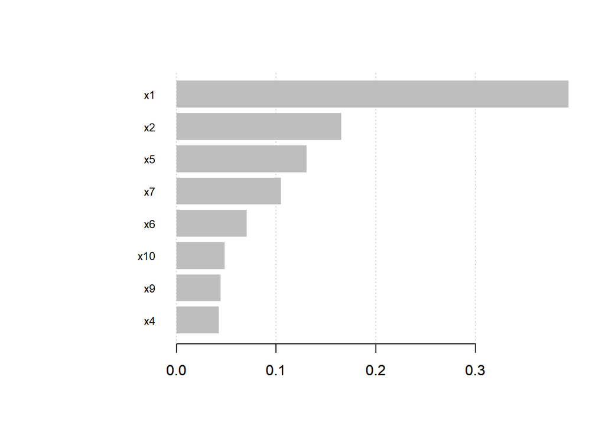

```r
xgb.importance(model = old_data_xgb) %>%
  xgb.plot.importance(top_n = 11)
```

##### new data

###### regression

```r
new_data_lm <- lm(md,data = sim_2)



new_data_lm %>% summary()
```

```
##
## Call:
## lm(formula = md, data = sim_2)
##
## Residuals:
##     Min      1Q  Median      3Q     Max
## -35.843  -7.269   0.131   7.939  30.860
##
## Coefficients:
##             Estimate Std. Error t value Pr(>|t|)
## (Intercept)   0.5373     1.4326   0.375 0.708513
## x1            9.4003     1.3447   6.990 4.44e-10 ***
## x2            5.9590     1.4757   4.038 0.000112 ***
## x4            7.0212     1.4280   4.917 3.88e-06 ***
## x5            4.6080     1.4718   3.131 0.002344 **
## x6           -7.6940     1.3956  -5.513 3.27e-07 ***
## x7            7.4268     1.4738   5.039 2.36e-06 ***
## x9            7.6092     1.4567   5.224 1.10e-06 ***
## x10          -5.1254     1.4718  -3.482 0.000766 ***
## ---
## Signif. codes:  0 '***' 0.001 '**' 0.01 '*' 0.05 '.' 0.1 ' ' 1
##
## Residual standard error: 13.7 on 91 degrees of freedom
## Multiple R-squared:  0.641,  Adjusted R-squared:  0.6094
## F-statistic: 20.31 on 8 and 91 DF,  p-value: < 2.2e-16
```

```r
print("train MSE")
```

```
## [1] "train MSE"
```

```r
label  <- new_data_lm %>% predict(sim_2)
mean((sim_2$y-label)^2)
```

```
## [1] 170.8588
```

```r
print("test MSE")
```

```
## [1] "test MSE"
```

```r
label  <- new_data_lm %>% predict(sim_3)
mean((sim_3$y-label)^2)
```

```
## [1] 216.6385
```

###### XGboost

```r
new_data_xgb <- xgboost(data = data.matrix(sim_2[,VS]),
label = sim_2[,"y"],
eta = 0.5,
max_depth = 10,
nround=25,
subsample = 0.7,
colsample_bytree = 0.7,
objective = "reg:squarederror",
verbose = 0
)
print("train MSE")
```

```
## [1] "train MSE"
```

```r
label  <- predict(new_data_xgb,xgb.DMatrix(data.matrix(sim_2[,VS])))
mean((sim_2$y-label)^2)
```

```
## [1] 0.06520776
```

```r
print("test MSE")
```

```
## [1] "test MSE"
```

```r
label  <- predict(new_data_xgb,xgb.DMatrix(data.matrix(sim_3[,VS])))
mean((sim_3$y-label)^2)
```

```
## [1] 403.9128
```

```r
xgb.importance(model = new_data_xgb)
```

| Feature | Gain | Cover | Frequency |
| --- | --- | --- | --- |
| x1 | 0.19159696 | 0.15072934 | 0.20922385 |
| x9 | 0.14147895 | 0.11085900 | 0.07986502 |
| x4 | 0.13960779 | 0.15429498 | 0.16422947 |
| x7 | 0.13932216 | 0.09465154 | 0.07536558 |
| x10 | 0.11484715 | 0.07163695 | 0.06299213 |
| x2 | 0.10878903 | 0.08379254 | 0.13610799 |
| x5 | 0.08317427 | 0.21669368 | 0.16872891 |
| x6 | 0.08118370 | 0.11734198 | 0.10348706 |

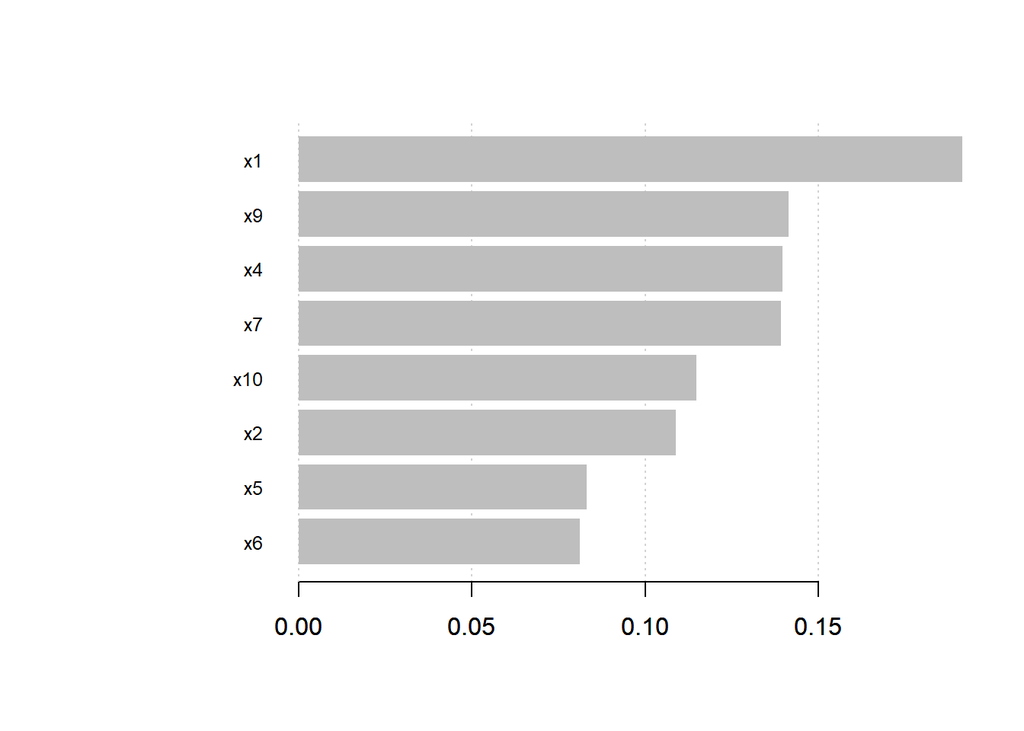

```r
xgb.importance(model = new_data_xgb) %>%
  xgb.plot.importance(top_n = 11)
```

### 第三次

```r
set.seed(1443)
x <- rmvnorm(n = 100,mean = c(0,0,0,0,0,0,0,0,0,0),sigma = diag(1,10))
set.seed(5697)
x_11 <- rnorm(n = 100)
set.seed(1005)
sd <- rnorm(100,sd = 4)
y <- 10*x[,1]+5*x[,2]-3*x[,3]+4*x[,4]+8*x[,5]-7*x[,6]+9*x[,7]-2*x[,8]+5*x[,9]-4*x[,10]+10*x[,1]*x[,2]-7*x[,3]*x[,4]+sd
sim <- data.frame(y,x,x_11)


set.seed(13232)
x <- rmvnorm(n = 100,mean = c(0,0,0,0,0,0,0,0,0,0),sigma = diag(1,10))
set.seed(1009)
x_11 <- rnorm(n = 100)
set.seed(547)
sd <- rnorm(100,sd = 4)
y <- 10*x[,1]+5*x[,2]-3*x[,3]+4*x[,4]+8*x[,5]-7*x[,6]+9*x[,7]-2*x[,8]+5*x[,9]-4*x[,10]+10*x[,1]*x[,2]-7*x[,3]*x[,4]+sd
sim_2 <- data.frame(y,x,x_11)


set.seed(1232)
x <- rmvnorm(n = 100,mean = c(0,0,0,0,0,0,0,0,0,0),sigma = diag(1,10))
set.seed(5659)
x_11 <- rnorm(n = 100)
set.seed(5867)
sd <- rnorm(100,sd = 4)
y <- 10*x[,1]+5*x[,2]-3*x[,3]+4*x[,4]+8*x[,5]-7*x[,6]+9*x[,7]-2*x[,8]+5*x[,9]-4*x[,10]+10*x[,1]*x[,2]-7*x[,3]*x[,4]+sd
sim_3 <- data.frame(y,x,x_11)





names(sim) <- c("y",paste0("x",1:11))
names(sim_2) <- c("y",paste0("x",1:11))
names(sim_3) <- c("y",paste0("x",1:11))
```

#### use p-value to Variable Selection

```r
(old_data_lm <- lm(y~.,data = sim) %>% ols_step_forward_p())
```

```
##
##                              Selection Summary
## ---------------------------------------------------------------------------
##         Variable                  Adj.
## Step    Entered     R-Square    R-Square      C(p)        AIC        RMSE
## ---------------------------------------------------------------------------
##    1    x7            0.2574      0.2498    153.5596    880.5866    19.3772
##    2    x1            0.4155      0.4034    102.4333    858.6491    17.2798
##    3    x5            0.5224      0.5074     68.5079    840.4511    15.7011
##    4    x9            0.5763      0.5585     52.3803    830.4670    14.8655
##    5    x10           0.6196      0.5994     39.8261    821.6839    14.1600
##    6    x2            0.6461      0.6233     32.9177    816.4600    13.7309
##    7    x4            0.6764      0.6518     24.7541    809.5258    13.2022
##    8    x3            0.7017      0.6755     18.2397    803.3733    12.7443
##    9    x6            0.7208      0.6929     13.8269    798.7619    12.3982
##   10    x8            0.7371      0.7075     10.3570    794.7554    12.0988
## ---------------------------------------------------------------------------
```

```r
md <- formula(y~.-x11)
VS <- 1:10+1
```

##### old data

###### regression

```r
old_data_lm$model %>% summary()
```

```
##
## Call:
## lm(formula = paste(response, "~", paste(preds, collapse = " + ")),
##     data = l)
##
## Residuals:
##     Min      1Q  Median      3Q     Max
## -27.769  -7.337  -0.656   6.781  41.669
##
## Coefficients:
##             Estimate Std. Error t value Pr(>|t|)
## (Intercept)  -0.3113     1.2503  -0.249 0.803984
## x7           10.8564     1.1820   9.185 1.56e-14 ***
## x1           10.2773     1.2709   8.087 2.89e-12 ***
## x5            8.0945     1.2935   6.258 1.34e-08 ***
## x9            5.2631     1.2385   4.250 5.26e-05 ***
## x10          -5.6166     1.2481  -4.500 2.05e-05 ***
## x2            5.0011     1.3362   3.743 0.000322 ***
## x4            4.4174     1.2185   3.625 0.000481 ***
## x3           -3.4104     1.2009  -2.840 0.005591 **
## x6           -3.3886     1.2769  -2.654 0.009429 **
## x8           -2.6601     1.1333  -2.347 0.021130 *
## ---
## Signif. codes:  0 '***' 0.001 '**' 0.01 '*' 0.05 '.' 0.1 ' ' 1
##
## Residual standard error: 12.1 on 89 degrees of freedom
## Multiple R-squared:  0.7371, Adjusted R-squared:  0.7075
## F-statistic: 24.95 on 10 and 89 DF,  p-value: < 2.2e-16
```

```r
print("train MSE")
```

```
## [1] "train MSE"
```

```r
label  <- old_data_lm$model %>% predict(sim)
mean((sim$y-label)^2)
```

```
## [1] 130.2788
```

```r
print("test MSE")
```

```
## [1] "test MSE"
```

```r
label  <- old_data_lm$model %>% predict(sim_3)
mean((sim_3$y-label)^2)
```

```
## [1] 167.5278
```

###### XGboost

```r
old_data_xgb <- xgboost(data = data.matrix(sim[,VS]),
label = sim[,"y"],
eta = 0.5,
max_depth = 10,
nround=25,
subsample = 0.7,
colsample_bytree = 0.7,
objective = "reg:squarederror",
verbose = 0
)
print("train MSE")
```

```
## [1] "train MSE"
```

```r
label  <- predict(old_data_xgb,xgb.DMatrix(data.matrix(sim[,VS])))
mean((sim$y-label)^2)
```

```
## [1] 0.02413359
```

```r
print("test MSE")
```

```
## [1] "test MSE"
```

```r
label  <- predict(old_data_xgb,xgb.DMatrix(data.matrix(sim_3[,VS])))
mean((sim_3$y-label)^2)
```

```
## [1] 371.055
```

```r
xgb.importance(model = old_data_xgb)
```

| Feature | Gain | Cover | Frequency |
| --- | --- | --- | --- |
| x7 | 0.25932568 | 0.07120933 | 0.05276705 |
| x5 | 0.19186711 | 0.04481277 | 0.05019305 |
| x1 | 0.16582434 | 0.14556476 | 0.21750322 |
| x2 | 0.14567396 | 0.17334254 | 0.16216216 |
| x10 | 0.07304926 | 0.07558318 | 0.05148005 |
| x8 | 0.05051210 | 0.09177409 | 0.08880309 |
| x6 | 0.03691893 | 0.10090546 | 0.09266409 |
| x9 | 0.03002834 | 0.06008287 | 0.05276705 |
| x3 | 0.02633275 | 0.13996317 | 0.12355212 |
| x4 | 0.02046752 | 0.09676182 | 0.10810811 |

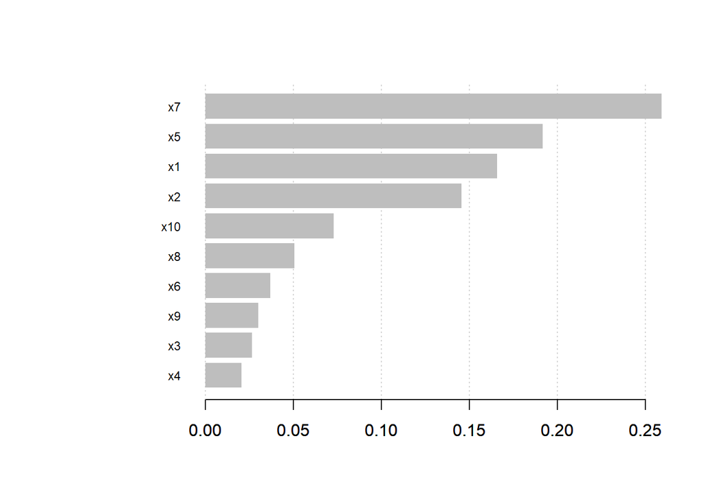

```r
xgb.importance(model = old_data_xgb) %>%
  xgb.plot.importance(top_n = 11)
```

##### new data

###### regression

```r
new_data_lm <- lm(md,data = sim_2)



new_data_lm %>% summary()
```

```
##
## Call:
## lm(formula = md, data = sim_2)
##
## Residuals:
##     Min      1Q  Median      3Q     Max
## -35.237  -6.823  -0.519   7.524  49.054
##
## Coefficients:
##             Estimate Std. Error t value Pr(>|t|)
## (Intercept)    0.168      1.364   0.123  0.90227
## x1             9.206      1.205   7.641 2.36e-11 ***
## x2             8.678      1.513   5.735 1.32e-07 ***
## x3            -4.091      1.503  -2.721  0.00783 **
## x4             4.266      1.260   3.385  0.00106 **
## x5            10.007      1.306   7.661 2.14e-11 ***
## x6            -9.148      1.445  -6.332 9.59e-09 ***
## x7             7.971      1.274   6.257 1.34e-08 ***
## x8            -2.920      1.415  -2.063  0.04204 *
## x9             3.593      1.354   2.653  0.00944 **
## x10           -3.570      1.333  -2.678  0.00882 **
## ---
## Signif. codes:  0 '***' 0.001 '**' 0.01 '*' 0.05 '.' 0.1 ' ' 1
##
## Residual standard error: 13.21 on 89 degrees of freedom
## Multiple R-squared:  0.7709, Adjusted R-squared:  0.7451
## F-statistic: 29.95 on 10 and 89 DF,  p-value: < 2.2e-16
```

```r
print("train MSE")
```

```
## [1] "train MSE"
```

```r
label  <- new_data_lm %>% predict(sim_2)
mean((sim_2$y-label)^2)
```

```
## [1] 155.2747
```

```r
print("test MSE")
```

```
## [1] "test MSE"
```

```r
label  <- new_data_lm %>% predict(sim_3)
mean((sim_3$y-label)^2)
```

```
## [1] 172.8843
```

###### XGboost

```r
new_data_xgb <- xgboost(data = data.matrix(sim_2[,VS]),
label = sim_2[,"y"],
eta = 0.5,
max_depth = 10,
nround=25,
subsample = 0.7,
colsample_bytree = 0.7,
objective = "reg:squarederror",
verbose = 0
)
print("train MSE")
```

```
## [1] "train MSE"
```

```r
label  <- predict(new_data_xgb,xgb.DMatrix(data.matrix(sim_2[,VS])))
mean((sim_2$y-label)^2)
```

```
## [1] 0.02514161
```

```r
print("test MSE")
```

```
## [1] "test MSE"
```

```r
label  <- predict(new_data_xgb,xgb.DMatrix(data.matrix(sim_3[,VS])))
mean((sim_3$y-label)^2)
```

```
## [1] 409.5524
```

```r
xgb.importance(model = new_data_xgb)
```

| Feature | Gain | Cover | Frequency |
| --- | --- | --- | --- |
| x1 | 0.20760169 | 0.20452903 | 0.25679012 |
| x2 | 0.18673972 | 0.10985305 | 0.14074074 |
| x6 | 0.11877743 | 0.10527584 | 0.08888889 |
| x5 | 0.11333607 | 0.12591343 | 0.07654321 |
| x8 | 0.08367905 | 0.06640970 | 0.05432099 |
| x3 | 0.07098431 | 0.09451538 | 0.12222222 |
| x7 | 0.06534928 | 0.08865334 | 0.07037037 |
| x10 | 0.06392235 | 0.07339597 | 0.05185185 |
| x9 | 0.05662199 | 0.05460532 | 0.03950617 |
| x4 | 0.03298809 | 0.07684895 | 0.09876543 |

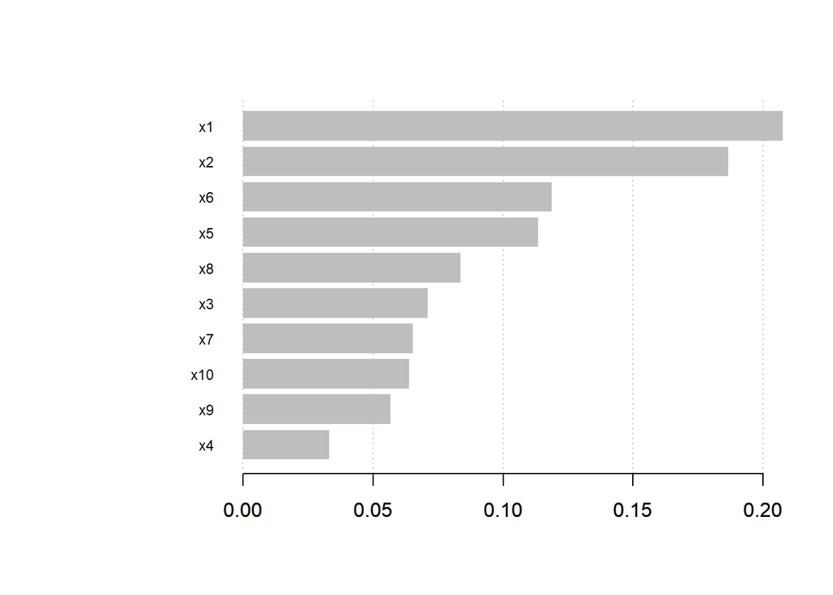

```r
xgb.importance(model = new_data_xgb) %>%
  xgb.plot.importance(top_n = 11)
```

#### use Gain to Variable Selection

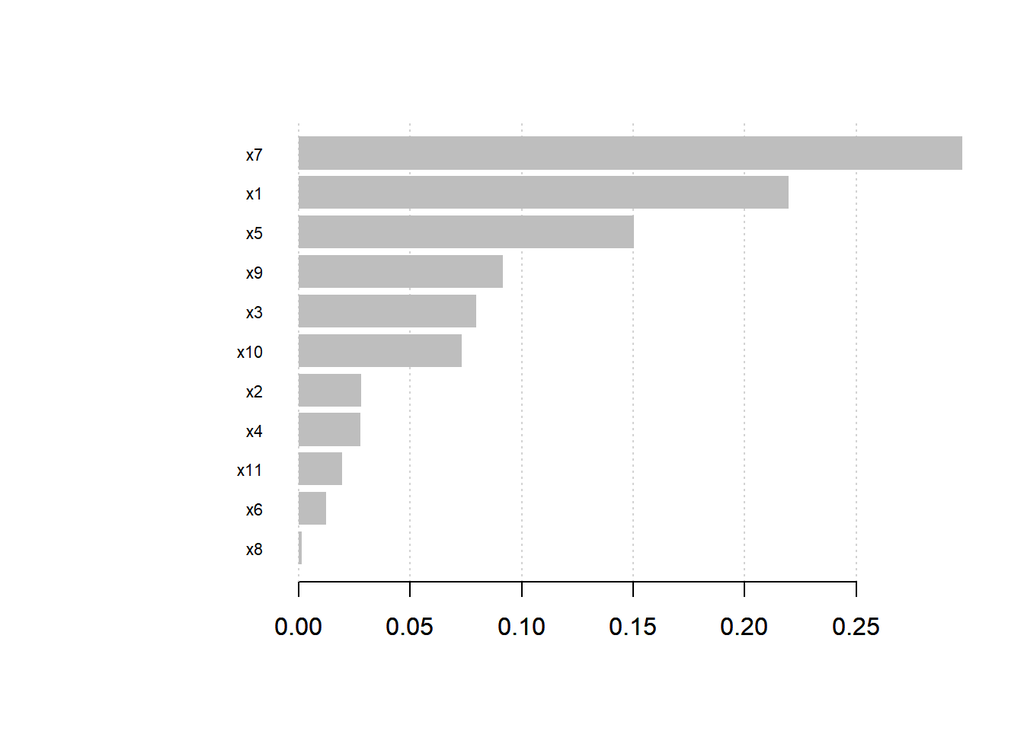

```r
xgb_test <- xgboost(data = data.matrix(sim[,-1]),
label = sim[,"y"],
eta = 0.5,
max_depth = 10,
nround=25,
subsample = 0.7,
colsample_bytree = 0.7,
objective = "reg:squarederror",
verbose = 0
)

xgb.importance(model = xgb_test) %>%
  xgb.plot.importance(top_n = 11)
```

```r
md <- formula(y~.-x11)
VS <- 1:10+1
```

##### old data

###### regression

```r
old_data_lm <- lm(md,data = sim)



old_data_lm %>% summary()
```

```
##
## Call:
## lm(formula = md, data = sim)
##
## Residuals:
##     Min      1Q  Median      3Q     Max
## -27.769  -7.337  -0.656   6.781  41.669
##
## Coefficients:
##             Estimate Std. Error t value Pr(>|t|)
## (Intercept)  -0.3113     1.2503  -0.249 0.803984
## x1           10.2773     1.2709   8.087 2.89e-12 ***
## x2            5.0011     1.3362   3.743 0.000322 ***
## x3           -3.4104     1.2009  -2.840 0.005591 **
## x4            4.4174     1.2185   3.625 0.000481 ***
## x5            8.0945     1.2935   6.258 1.34e-08 ***
## x6           -3.3886     1.2769  -2.654 0.009429 **
## x7           10.8564     1.1820   9.185 1.56e-14 ***
## x8           -2.6601     1.1333  -2.347 0.021130 *
## x9            5.2631     1.2385   4.250 5.26e-05 ***
## x10          -5.6166     1.2481  -4.500 2.05e-05 ***
## ---
## Signif. codes:  0 '***' 0.001 '**' 0.01 '*' 0.05 '.' 0.1 ' ' 1
##
## Residual standard error: 12.1 on 89 degrees of freedom
## Multiple R-squared:  0.7371, Adjusted R-squared:  0.7075
## F-statistic: 24.95 on 10 and 89 DF,  p-value: < 2.2e-16
```

```r
print("train MSE")
```

```
## [1] "train MSE"
```

```r
label  <- old_data_lm %>% predict(sim)
mean((sim$y-label)^2)
```

```
## [1] 130.2788
```

```r
print("test MSE")
```

```
## [1] "test MSE"
```

```r
label  <- old_data_lm %>% predict(sim_3)
mean((sim_3$y-label)^2)
```

```
## [1] 167.5278
```

###### XGboost

```r
old_data_xgb <- xgboost(data = data.matrix(sim[,VS]),
label = sim[,"y"],
eta = 0.5,
max_depth = 10,
nround=25,
subsample = 0.7,
colsample_bytree = 0.7,
objective = "reg:squarederror",
verbose = 0
)
print("train MSE")
```

```
## [1] "train MSE"
```

```r
label  <- predict(old_data_xgb,xgb.DMatrix(data.matrix(sim[,VS])))
mean((sim$y-label)^2)
```

```
## [1] 0.01304306
```

```r
print("test MSE")
```

```
## [1] "test MSE"
```

```r
label  <- predict(old_data_xgb,xgb.DMatrix(data.matrix(sim_3[,VS])))
mean((sim_3$y-label)^2)
```

```
## [1] 287.8122
```

```r
xgb.importance(model = old_data_xgb)
```

| Feature | Gain | Cover | Frequency |
| --- | --- | --- | --- |
| x1 | 0.27953263 | 0.22997596 | 0.25353925 |
| x7 | 0.19402059 | 0.08094906 | 0.06949807 |
| x2 | 0.17030271 | 0.13941227 | 0.17889318 |
| x5 | 0.13117238 | 0.11429014 | 0.09523810 |
| x8 | 0.05206401 | 0.04861596 | 0.06048906 |
| x4 | 0.04648574 | 0.08645421 | 0.07593308 |
| x6 | 0.03883639 | 0.04830581 | 0.05019305 |
| x3 | 0.03504575 | 0.11839963 | 0.11068211 |
| x9 | 0.03016274 | 0.07761495 | 0.05534106 |
| x10 | 0.02237705 | 0.05598201 | 0.05019305 |

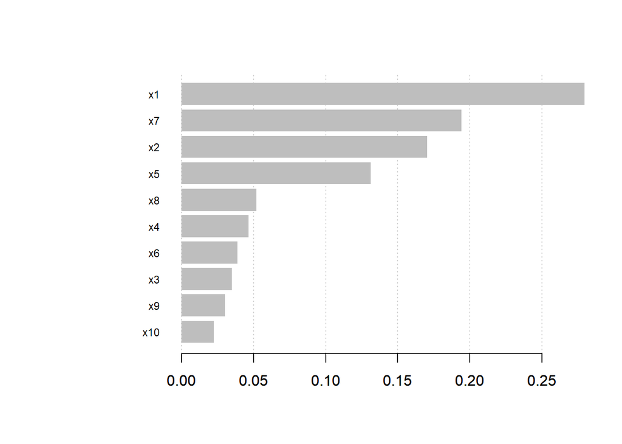

```r
xgb.importance(model = old_data_xgb) %>%
  xgb.plot.importance(top_n = 11)
```

##### new data

###### regression

```r
new_data_lm <- lm(md,data = sim_2)



new_data_lm %>% summary()
```

```
##
## Call:
## lm(formula = md, data = sim_2)
##
## Residuals:
##     Min      1Q  Median      3Q     Max
## -35.237  -6.823  -0.519   7.524  49.054
##
## Coefficients:
##             Estimate Std. Error t value Pr(>|t|)
## (Intercept)    0.168      1.364   0.123  0.90227
## x1             9.206      1.205   7.641 2.36e-11 ***
## x2             8.678      1.513   5.735 1.32e-07 ***
## x3            -4.091      1.503  -2.721  0.00783 **
## x4             4.266      1.260   3.385  0.00106 **
## x5            10.007      1.306   7.661 2.14e-11 ***
## x6            -9.148      1.445  -6.332 9.59e-09 ***
## x7             7.971      1.274   6.257 1.34e-08 ***
## x8            -2.920      1.415  -2.063  0.04204 *
## x9             3.593      1.354   2.653  0.00944 **
## x10           -3.570      1.333  -2.678  0.00882 **
## ---
## Signif. codes:  0 '***' 0.001 '**' 0.01 '*' 0.05 '.' 0.1 ' ' 1
##
## Residual standard error: 13.21 on 89 degrees of freedom
## Multiple R-squared:  0.7709, Adjusted R-squared:  0.7451
## F-statistic: 29.95 on 10 and 89 DF,  p-value: < 2.2e-16
```

```r
print("train MSE")
```

```
## [1] "train MSE"
```

```r
label  <- new_data_lm %>% predict(sim_2)
mean((sim_2$y-label)^2)
```

```
## [1] 155.2747
```

```r
print("test MSE")
```

```
## [1] "test MSE"
```

```r
label  <- new_data_lm %>% predict(sim_3)
mean((sim_3$y-label)^2)
```

```
## [1] 172.8843
```

###### XGboost

```r
new_data_xgb <- xgboost(data = data.matrix(sim_2[,VS]),
label = sim_2[,"y"],
eta = 0.5,
max_depth = 10,
nround=25,
subsample = 0.7,
colsample_bytree = 0.7,
objective = "reg:squarederror",
verbose = 0
)
print("train MSE")
```

```
## [1] "train MSE"
```

```r
label  <- predict(new_data_xgb,xgb.DMatrix(data.matrix(sim_2[,VS])))
mean((sim_2$y-label)^2)
```

```
## [1] 0.02301319
```

```r
print("test MSE")
```

```
## [1] "test MSE"
```

```r
label  <- predict(new_data_xgb,xgb.DMatrix(data.matrix(sim_3[,VS])))
mean((sim_3$y-label)^2)
```

```
## [1] 367.9726
```

```r
xgb.importance(model = new_data_xgb)
```

| Feature | Gain | Cover | Frequency |
| --- | --- | --- | --- |
| x1 | 0.26411398 | 0.25975930 | 0.28329298 |
| x6 | 0.24491804 | 0.06773646 | 0.05447942 |
| x4 | 0.09279742 | 0.07645425 | 0.09564165 |
| x2 | 0.09189520 | 0.09504706 | 0.13801453 |
| x5 | 0.08437034 | 0.09342694 | 0.07384988 |
| x9 | 0.06591254 | 0.07537417 | 0.05811138 |
| x7 | 0.05740886 | 0.10847091 | 0.06779661 |
| x3 | 0.05469495 | 0.09751582 | 0.11864407 |
| x8 | 0.03370688 | 0.06141028 | 0.06053269 |
| x10 | 0.01018179 | 0.06480481 | 0.04963680 |

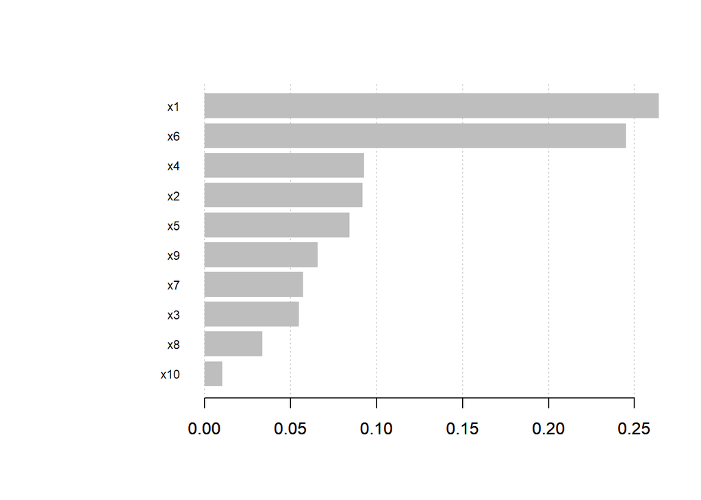

```r
xgb.importance(model = new_data_xgb) %>%
  xgb.plot.importance(top_n = 11)
```

## 資料三(只有交互作用項)

regression的表現又更差了，train和test的MSE差距更大了。  
XGboost還是差不多的狀況。

$x_{1 \sim 10}\sim MN(\mu , \Sigma )$ $\mu=(0,0,0,0,0,0,0,0,0,0)$
$$\Sigma = \begin{pmatrix}
1 & 0 & 0 & 0 & 0 & 0 & 0 & 0 & 0 & 0\\
0 & 1& 0 & 0 & 0 & 0 & 0 & 0 & 0 & 0\\
0 & 0& 1 & 0 & 0 & 0 & 0 & 0 & 0 & 0\\
0 & 0& 0 & 1 & 0 & 0 & 0 & 0 & 0 & 0\\
0 & 0& 0 & 0 & 1 & 0 & 0 & 0 & 0 & 0\\
0 & 0& 0 & 0 & 0 & 1 & 0 & 0 & 0 & 0\\
0 & 0& 0 & 0 & 0 & 0 & 1 & 0 & 0 & 0\\
0 & 0& 0 & 0 & 0 & 0 & 0 & 1 & 0 & 0\\
0 & 0& 0 & 0 & 0 & 0 & 0 & 0 & 1 & 0\\
0 & 0& 0 & 0 & 0 & 0 & 0 & 0 & 0 & 1
\end{pmatrix}$$

$x_{11} \sim N(0,1)$

$y=+10x_1x_2-7x_3x_4-8x_6x_9+\epsilon$

$\epsilon \sim N(0,4)$

### 第一次

```r
set.seed(1423)
x <- rmvnorm(n = 100,mean = c(0,0,0,0,0,0,0,0,0,0),sigma = diag(1,10))
set.seed(597)
x_11 <- rnorm(n = 100)
set.seed(55)
sd <- rnorm(100,sd = 4)
y <- 10*x[,1]*x[,2]-7*x[,3]*x[,4]-8*x[,6]*x[,9]+sd
sim <- data.frame(y,x,x_11)


set.seed(1232)
x <- rmvnorm(n = 100,mean = c(0,0,0,0,0,0,0,0,0,0),sigma = diag(1,10))
set.seed(599)
x_11 <- rnorm(n = 100)
set.seed(57)
sd <- rnorm(100,sd = 4)
y <- 10*x[,1]*x[,2]-7*x[,3]*x[,4]-8*x[,6]*x[,9]+sd
sim_2 <- data.frame(y,x,x_11)

set.seed(1252)
x <- rmvnorm(n = 100,mean = c(0,0,0,0,0,0,0,0,0,0),sigma = diag(1,10))
set.seed(5679)
x_11 <- rnorm(n = 100)
set.seed(512)
sd <- rnorm(100,sd = 4)
y <- 10*x[,1]*x[,2]-7*x[,3]*x[,4]-8*x[,6]*x[,9]+sd
sim_3 <- data.frame(y,x,x_11)




names(sim) <- c("y",paste0("x",1:11))
names(sim_2) <- c("y",paste0("x",1:11))
names(sim_3) <- c("y",paste0("x",1:11))
```

#### use p-value to Variable Selection

```r
(old_data_lm <- lm(y~.,data = sim) %>% ols_step_forward_p())
```

```
##
##                             Selection Summary
## -------------------------------------------------------------------------
##         Variable                  Adj.
## Step    Entered     R-Square    R-Square     C(p)       AIC        RMSE
## -------------------------------------------------------------------------
##    1    x6            0.0434      0.0337    5.1501    814.2716    13.9088
##    2    x9            0.0705      0.0514    4.2859    813.3992    13.7809
##    3    x5            0.1039      0.0759    2.7545    811.7400    13.6014
##    4    x10           0.1232      0.0863    2.7131    811.5621    13.5247
##    5    x1            0.1355      0.0895    3.4173    812.1545    13.5011
##    6    x3            0.1477      0.0927    4.1229    812.7285    13.4771
## -------------------------------------------------------------------------
```

```r
md <- formula(y~x1+x3+x5+x6+x9+x10)
VS <- c(1,3,5,6,9,10)+1
```

##### old data

###### regression

```r
old_data_lm$model %>% summary()
```

```
##
## Call:
## lm(formula = paste(response, "~", paste(preds, collapse = " + ")),
##     data = l)
##
## Residuals:
##     Min      1Q  Median      3Q     Max
## -54.425  -6.134   0.799   7.692  27.197
##
## Coefficients:
##             Estimate Std. Error t value Pr(>|t|)
## (Intercept)  -0.7472     1.4018  -0.533   0.5953
## x6            2.7043     1.3547   1.996   0.0488 *
## x9            2.9486     1.3931   2.117   0.0370 *
## x5           -2.1354     1.3509  -1.581   0.1173
## x10          -1.7202     1.2006  -1.433   0.1553
## x1            2.0606     1.5653   1.316   0.1913
## x3           -1.7766     1.5373  -1.156   0.2508
## ---
## Signif. codes:  0 '***' 0.001 '**' 0.01 '*' 0.05 '.' 0.1 ' ' 1
##
## Residual standard error: 13.48 on 93 degrees of freedom
## Multiple R-squared:  0.1477, Adjusted R-squared:  0.09274
## F-statistic: 2.687 on 6 and 93 DF,  p-value: 0.01891
```

```r
print("train MSE")
```

```
## [1] "train MSE"
```

```r
label  <- old_data_lm$model %>% predict(sim)
mean((sim$y-label)^2)
```

```
## [1] 168.9171
```

```r
print("test MSE")
```

```
## [1] "test MSE"
```

```r
label  <- old_data_lm$model %>% predict(sim_3)
mean((sim_3$y-label)^2)
```

```
## [1] 343.8394
```

###### XGboost

```r
old_data_xgb <- xgboost(data = data.matrix(sim[,VS]),
label = sim[,"y"],
eta = 0.5,
max_depth = 10,
nround=25,
subsample = 0.7,
colsample_bytree = 0.7,
objective = "reg:squarederror",
verbose = 0
)
print("train MSE")
```

```
## [1] "train MSE"
```

```r
label  <- predict(old_data_xgb,xgb.DMatrix(data.matrix(sim[,VS])))
mean((sim$y-label)^2)
```

```
## [1] 0.02507772
```

```r
print("test MSE")
```

```
## [1] "test MSE"
```

```r
label  <- predict(old_data_xgb,xgb.DMatrix(data.matrix(sim_3[,VS])))
mean((sim_3$y-label)^2)
```

```
## [1] 341.2125
```

```r
xgb.importance(model = old_data_xgb)
```

| Feature | Gain | Cover | Frequency |
| --- | --- | --- | --- |
| x1 | 0.2474067 | 0.28140079 | 0.3009815 |
| x10 | 0.1947304 | 0.20470829 | 0.1363141 |
| x5 | 0.1661721 | 0.12889311 | 0.1243184 |
| x3 | 0.1439936 | 0.13020909 | 0.2039258 |
| x6 | 0.1373615 | 0.09796754 | 0.1101418 |
| x9 | 0.1103357 | 0.15682117 | 0.1243184 |

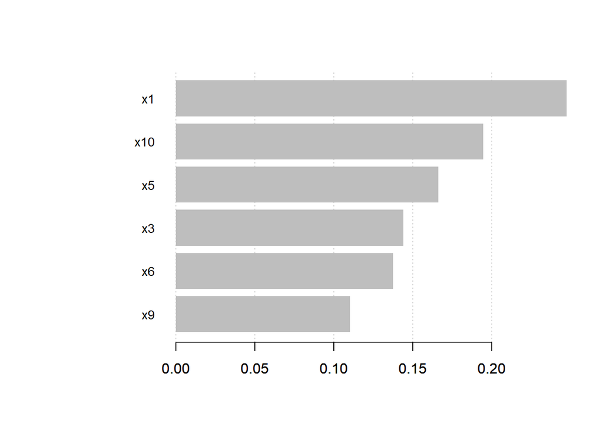

```r
xgb.importance(model = old_data_xgb) %>%
  xgb.plot.importance(top_n = 11)
```

##### new data

###### regression

```r
new_data_lm <- lm(md,data = sim_2)



new_data_lm %>% summary()
```

```
##
## Call:
## lm(formula = md, data = sim_2)
##
## Residuals:
##     Min      1Q  Median      3Q     Max
## -39.584  -7.410   1.337   8.199  31.888
##
## Coefficients:
##             Estimate Std. Error t value Pr(>|t|)
## (Intercept)  -0.9047     1.4256  -0.635    0.527
## x1            0.5629     1.4401   0.391    0.697
## x3           -0.1657     1.4485  -0.114    0.909
## x5           -1.7389     1.4464  -1.202    0.232
## x6           -0.3212     1.6024  -0.200    0.842
## x9            1.8680     1.4031   1.331    0.186
## x10           1.4307     1.2948   1.105    0.272
##
## Residual standard error: 13.83 on 93 degrees of freedom
## Multiple R-squared:  0.04169,    Adjusted R-squared:  -0.02014
## F-statistic: 0.6742 on 6 and 93 DF,  p-value: 0.6707
```

```r
print("train MSE")
```

```
## [1] "train MSE"
```

```r
label  <- new_data_lm %>% predict(sim_2)
mean((sim_2$y-label)^2)
```

```
## [1] 177.7599
```

```r
print("test MSE")
```

```
## [1] "test MSE"
```

```r
label  <- new_data_lm %>% predict(sim_3)
mean((sim_3$y-label)^2)
```

```
## [1] 307.3119
```

###### XGboost

```r
new_data_xgb <- xgboost(data = data.matrix(sim_2[,VS]),
label = sim_2[,"y"],
eta = 0.5,
max_depth = 10,
nround=25,
subsample = 0.7,
colsample_bytree = 0.7,
objective = "reg:squarederror",
verbose = 0
)
print("train MSE")
```

```
## [1] "train MSE"
```

```r
label  <- predict(new_data_xgb,xgb.DMatrix(data.matrix(sim_2[,VS])))
mean((sim_2$y-label)^2)
```

```
## [1] 0.05673716
```

```r
print("test MSE")
```

```
## [1] "test MSE"
```

```r
label  <- predict(new_data_xgb,xgb.DMatrix(data.matrix(sim_3[,VS])))
mean((sim_3$y-label)^2)
```

```
## [1] 331.8621
```

```r
xgb.importance(model = new_data_xgb)
```

| Feature | Gain | Cover | Frequency |
| --- | --- | --- | --- |
| x10 | 0.26782439 | 0.2039924 | 0.1169772 |
| x6 | 0.17834035 | 0.1663780 | 0.1573499 |
| x3 | 0.17325884 | 0.1922791 | 0.2691511 |
| x9 | 0.16792520 | 0.1615112 | 0.1190476 |
| x5 | 0.14817326 | 0.1502928 | 0.1708075 |
| x1 | 0.06447797 | 0.1255465 | 0.1666667 |

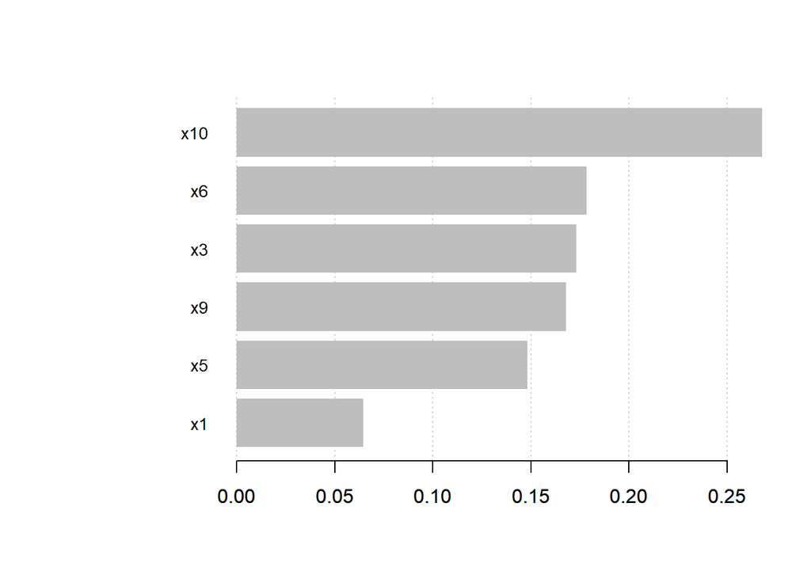

```r
xgb.importance(model = new_data_xgb) %>%
  xgb.plot.importance(top_n = 11)
```